# CaseStudy 2 RP

Rashmi Patel

4/5/2021

# Southern Methodist University 6306-Doing Data Science:Case Study 2

In this case study, we will do some analysis on the data given by the client: DDSAnalytics. The client is is interested in knowing the top influential factors that lead to attrition and high monthly income of an employee for their company.

For this analysis, we will do the following steps:

- Import and inspect the data
- Initial Data Cleaning
- Exploratory Data Analysis of the data
- Building the model
- Predicting the test data using the data
- Storing the predicted data in csv files

# Load the required libraries

```
## VIM is ready to use.
```

```
## Suggestions and bug-reports can be submitted at: https://github.com/statistikat/VIM/issues
```

# Import and inspect data

## Read the data from GitHub

- The data is fetched from github account.
- The data has 36 variables and 870 entries.
- 27 continuous variables and 9 categorical variables.
- Plot the histogram for all the variables

```r
case2 = read.csv("https://raw.githubusercontent.com/RashmiAPatel19/SMU_MSDS_6306_CaseStudy2_Spring2021/main/CaseStudy2-data.csv", header = TRUE)
head(case2)
```

```
##   ID Age Attrition    BusinessTravel DailyRate             Department
## 1  1  32        No     Travel_Rarely       117                  Sales
## 2  2  40        No     Travel_Rarely      1308 Research & Development
## 3  3  35        No Travel_Frequently       200 Research & Development
## 4  4  32        No     Travel_Rarely       801                  Sales
## 5  5  24        No Travel_Frequently       567 Research & Development
## 6  6  27        No Travel_Frequently       294 Research & Development
##   DistanceFromHome Education   EducationField EmployeeCount EmployeeNumber
## 1               13         4    Life Sciences             1            859
## 2               14         3          Medical             1           1128
## 3               18         2    Life Sciences             1           1412
## 4                1         4        Marketing             1           2016
## 5                2         1 Technical Degree             1           1646
## 6               10         2    Life Sciences             1            733
##   EnvironmentSatisfaction Gender HourlyRate JobInvolvement JobLevel
```

[output cut: 41 more lines]

```r
dim(case2)
```

```
## [1] 870  36
```

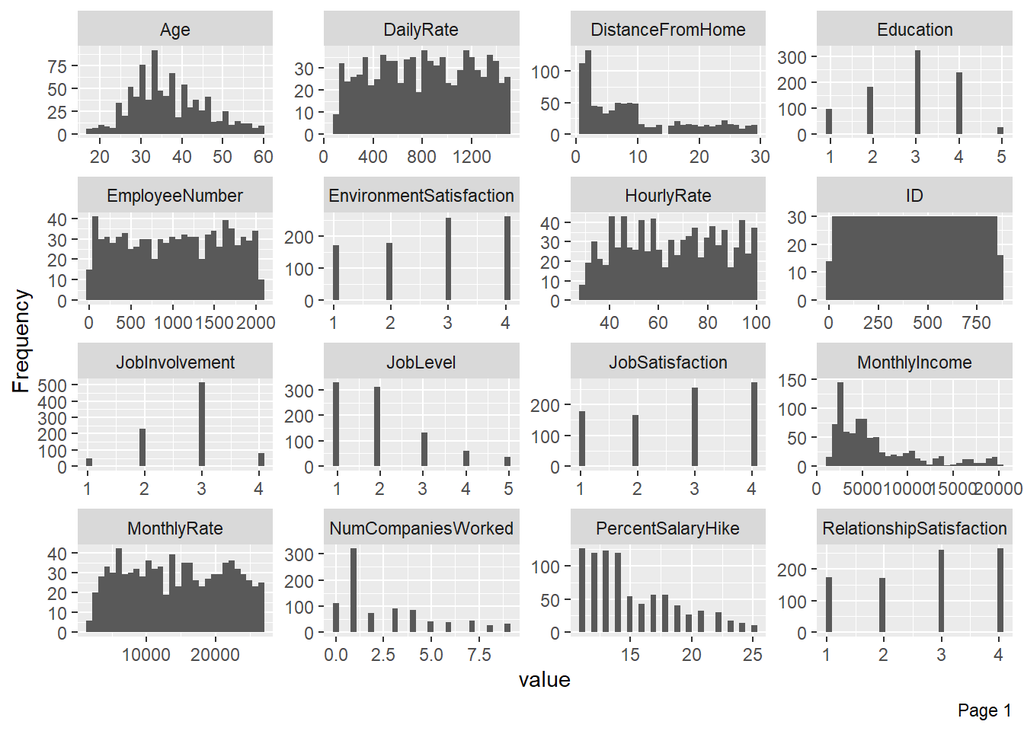

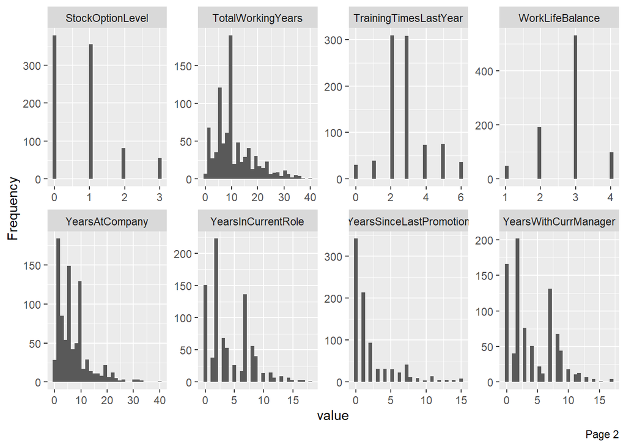

```r
plot_histogram(case2)
```

```r
str(case2)
```

```
## 'data.frame':    870 obs. of  36 variables:
##  $ ID                      : int  1 2 3 4 5 6 7 8 9 10 ...
##  $ Age                     : int  32 40 35 32 24 27 41 37 34 34 ...
##  $ Attrition               : chr  "No" "No" "No" "No" ...
##  $ BusinessTravel          : chr  "Travel_Rarely" "Travel_Rarely" "Travel_Frequently" "Travel_Rarely" ...
##  $ DailyRate               : int  117 1308 200 801 567 294 1283 309 1333 653 ...
##  $ Department              : chr  "Sales" "Research & Development" "Research & Development" "Sales" ...
##  $ DistanceFromHome        : int  13 14 18 1 2 10 5 10 10 10 ...
##  $ Education               : int  4 3 2 4 1 2 5 4 4 4 ...
##  $ EducationField          : chr  "Life Sciences" "Medical" "Life Sciences" "Marketing" ...
##  $ EmployeeCount           : int  1 1 1 1 1 1 1 1 1 1 ...
##  $ EmployeeNumber          : int  859 1128 1412 2016 1646 733 1448 1105 1055 1597 ...
##  $ EnvironmentSatisfaction : int  2 3 3 3 1 4 2 4 3 4 ...
##  $ Gender                  : chr  "Male" "Male" "Male" "Female" ...
##  $ HourlyRate              : int  73 44 60 48 32 32 90 88 87 92 ...
```

[output cut: 22 more lines]

```r
numeric_var_case2=sum(sapply(case2[,1:36],is.numeric))
```

# Initial Data Cleaning

## Check the variables with vague information and remove the variables

```r
# looking for correlation between DailyRate, HourlyRate, MonthlyRate, and Monthly income
income=data.frame(DailyRate=case2$DailyRate,MonthlyIncome=case2$MonthlyIncome,
                             HourlyRate=case2$HourlyRate,MonthlyRate=case2$MonthlyRate)
dim(income)
```

```
## [1] 870   4
```

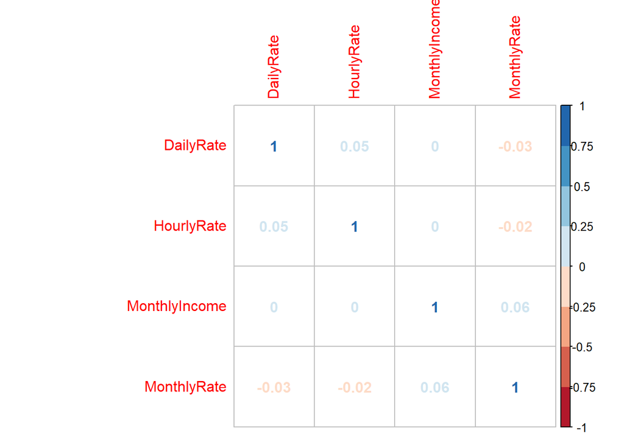

```r
corrplot(cor(income), order = "alphabet",
         col = brewer.pal(n = 8, name = "RdBu"),method="number")
```

```r
# Checking if the some employees are ages: But no employees were found under 18, so we will remove this variable
unique(case2$Over18)
```

```
## [1] "Y"
```

```r
# Checking for the unique employee count: But every employee count has value=1, so we will remove this variable
unique(case2$EmployeeCount)
```

```
## [1] 1
```

```r
#Checking the employee number: But no duplicate values were found, so we will remove this variable
unique(case2$EmployeeNumber)
```

```
##   [1]  859 1128 1412 2016 1646  733 1448 1105 1055 1597 1866 1858  845  508 1314
##  [16]  947  966  487 1755 1903  699  712  663 1613  969 1267 1582 1157 1968  791
##  [31]  195 1698  363 1172 1966  359 1639 1733 1338 1135 1824  783 1674 1595 1270
##  [46] 1480 1734 1119  614  218  662 1423 1246  972   98 1772  752 1586  380 1273
##  [61]  967 1312 1996 1839 1219   21  691 1982   88  391 1999 1469  261 1158 1319
##  [76]   57 1535 1602  302 1974 1033 1728 1997  474 1294 1032  728 1010   56   38
##  [91]  556 1165    4 1587  226  387 1527  139 1513 1447 1434 1453  523  705 1472
## [106] 1177  208 1973 1821 2038 1154  976 1118  771 1218  904 1240 2053  227 1383
## [121]  742 2021  864  709  388 1962   33 1888 1402 1863 1669 1757  551 1654  448
## [136]  807  816 1013  932  152 1373 1308 1007  378 1375  469  252 1560 1173 1622
## [151]  650  722  420 1814  934  475 1986 1127 1126 1242  104 1082  677  347  406
## [166]  922 1655  612  630 1120  747 1934  624 1268  981 1131  787 1053  207  230
## [181] 1182 1355  171 1525  602  377 1653 1676  385  129  441 1833  550  595 1407
## [196]  353  116 1138   36  643  986   96  830  741  330  913 1188  282  197  176
## [211] 2034 1029  715  827  700 1474  634 1900  194 1275  786  684 1681 1506 1940
```

[output cut: 43 more lines]

```r
# Checking he unique values in standard hours: But no values other than 80 found, so we will variable this variable
unique(case2$StandardHours)
```

```
## [1] 80
```

```r
# Checking the unique values of Performance rating: But the the values were kind of vague how it is assigned to employees,so we will remove this variable
unique(case2$PerformanceRating)
```

```
## [1] 3 4
```

```r
# Removing the DailyRate, HourlyRate, MonthlyRate because the the meaning is unclear
case2=select(case2,-c(ID,Over18, EmployeeCount, StandardHours, EmployeeNumber, DailyRate, HourlyRate, MonthlyRate, PerformanceRating))
dim(case2)
```

```
## [1] 870  27
```

```r
colnames(case2)
```

```
##  [1] "Age"                      "Attrition"
##  [3] "BusinessTravel"           "Department"
##  [5] "DistanceFromHome"         "Education"
##  [7] "EducationField"           "EnvironmentSatisfaction"
##  [9] "Gender"                   "JobInvolvement"
## [11] "JobLevel"                 "JobRole"
## [13] "JobSatisfaction"          "MaritalStatus"
## [15] "MonthlyIncome"            "NumCompaniesWorked"
## [17] "OverTime"                 "PercentSalaryHike"
## [19] "RelationshipSatisfaction" "StockOptionLevel"
## [21] "TotalWorkingYears"        "TrainingTimesLastYear"
## [23] "WorkLifeBalance"          "YearsAtCompany"
## [25] "YearsInCurrentRole"       "YearsSinceLastPromotion"
## [27] "YearsWithCurrManager"
```

## Plot histogram for analyzing Attrition

- We have plotted the histogram of Attrition to know about the Attrition in this data. We found that 730 employees says No for Attrition in this data and 140 employees says yes to Attrition in this data..

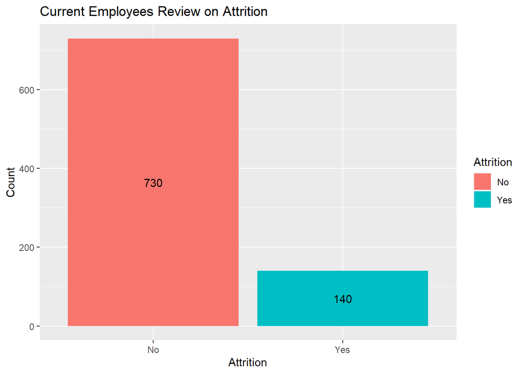

```r
ggplot(case2,aes(x=Attrition,fill=Attrition))+geom_bar()+
  geom_text(aes(label=..count..),stat="count",position=position_stack(0.5))+
  xlab("Attrition")+ylab("Count")+ggtitle("Current Employees Review on Attrition")
```

## Check the missing values and handling the missing values.

- We checked for missing values in the data and no missing values were found.
- We converted the character variables into integer.
- We then created a correlation plot to see the correlation between variables

```r
# Check for missing values
table(is.na(case2))
```

```
##
## FALSE
## 23490
```

```r
# Check for the total number of columns that are character and numeric in type
numeric_var_case2=sum(sapply(case2[,1:27],is.numeric))
numeric_var_case2
```

```
## [1] 19
```

```r
char_var_case2=sum(sapply(case2[,1:27],is.character))
char_var_case2
```

```
## [1] 8
```

```r
# Check for the names of  columns that are character and numeric in type
numeric_varname_case2=which(sapply(case2[,1:27],is.numeric))
numeric_varname_case2
```

```
##                      Age         DistanceFromHome                Education
##                        1                        5                        6
##  EnvironmentSatisfaction           JobInvolvement                 JobLevel
##                        8                       10                       11
##          JobSatisfaction            MonthlyIncome       NumCompaniesWorked
##                       13                       15                       16
##        PercentSalaryHike RelationshipSatisfaction         StockOptionLevel
##                       18                       19                       20
##        TotalWorkingYears    TrainingTimesLastYear          WorkLifeBalance
##                       21                       22                       23
##           YearsAtCompany       YearsInCurrentRole  YearsSinceLastPromotion
##                       24                       25                       26
##     YearsWithCurrManager
##                       27
```

```r
char_varname_case2=which(sapply(case2[,1:27],is.character))
char_varname_case2
```

```
##      Attrition BusinessTravel     Department EducationField         Gender
##              2              3              4              7              9
##        JobRole  MaritalStatus       OverTime
##             12             14             17
```

```r
case2_numeric=case2
var_facs <- c("Attrition","EducationField","MaritalStatus","BusinessTravel","JobRole", "Department", "OverTime", "Gender")
case2_numeric[,var_facs] <- lapply(case2[,var_facs] , factor, ordered = FALSE)

case2_numeric$JobRole <- as.integer(case2_numeric$JobRole)
case2_numeric$Department <- as.integer(case2_numeric$Department)
case2_numeric$MaritalStatus <- as.integer(case2_numeric$MaritalStatus)
case2_numeric$BusinessTravel <- as.integer(case2_numeric$BusinessTravel)
case2_numeric$Education <- as.integer(case2_numeric$Education)
case2_numeric$Attrition <- as.integer(case2_numeric$Attrition)
case2_numeric$OverTime <- as.integer(case2_numeric$OverTime)
case2_numeric$Gender <- as.integer(case2_numeric$Gender)
case2_numeric$EducationField <- as.integer(case2_numeric$EducationField)

str(case2_numeric)
```

```
## 'data.frame':    870 obs. of  27 variables:
##  $ Age                     : int  32 40 35 32 24 27 41 37 34 34 ...
##  $ Attrition               : int  1 1 1 1 1 1 1 1 1 1 ...
##  $ BusinessTravel          : int  3 3 2 3 2 2 3 3 3 2 ...
##  $ Department              : int  3 2 2 3 2 2 2 3 3 2 ...
##  $ DistanceFromHome        : int  13 14 18 1 2 10 5 10 10 10 ...
##  $ Education               : int  4 3 2 4 1 2 5 4 4 4 ...
##  $ EducationField          : int  2 4 2 3 6 2 4 2 2 6 ...
##  $ EnvironmentSatisfaction : int  2 3 3 3 1 4 2 4 3 4 ...
##  $ Gender                  : int  2 2 2 1 1 2 2 1 1 2 ...
##  $ JobInvolvement          : int  3 2 3 3 3 3 4 2 3 2 ...
##  $ JobLevel                : int  2 5 3 3 1 3 1 2 1 2 ...
##  $ JobRole                 : int  8 6 5 8 7 5 7 8 9 1 ...
##  $ JobSatisfaction         : int  4 3 4 4 4 1 3 4 3 3 ...
##  $ MaritalStatus           : int  1 3 3 2 3 1 2 1 2 2 ...
##  $ MonthlyIncome           : int  4403 19626 9362 10422 3760 8793 2127 6694 2220 5063 ...
##  $ NumCompaniesWorked      : int  2 1 2 1 1 1 2 2 1 1 ...
##  $ OverTime                : int  1 1 1 1 2 1 2 2 2 1 ...
##  $ PercentSalaryHike       : int  11 14 11 19 13 21 12 14 19 14 ...
##  $ RelationshipSatisfaction: int  3 1 3 3 3 3 1 3 4 2 ...
##  $ StockOptionLevel        : int  1 0 0 2 0 2 0 3 1 1 ...
##  $ TotalWorkingYears       : int  8 21 10 14 6 9 7 8 1 8 ...
##  $ TrainingTimesLastYear   : int  3 2 2 3 2 4 5 5 2 3 ...
##  $ WorkLifeBalance         : int  2 4 3 3 3 2 2 3 3 2 ...
##  $ YearsAtCompany          : int  5 20 2 14 6 9 4 1 1 8 ...
##  $ YearsInCurrentRole      : int  2 7 2 10 3 7 2 0 1 2 ...
##  $ YearsSinceLastPromotion : int  0 4 2 5 1 1 0 0 0 7 ...
##  $ YearsWithCurrManager    : int  3 9 2 7 3 7 3 0 0 7 ...
```

## Categorize the Monthly Income in “Under 2500, 2500-5000, 5000-7500, Above 7500”

- We decided to categorize the monthly income in 4 parts and create new column in the data:
- Under 2500 dollars
- 2500 to 5000 dollars
- 5000 to 7500 dollars
- Above 7500 dollars
- After creating new column we have 28 variables and 870 entries.

```r
summary(case2_numeric$MonthlyIncome)
```

```
##    Min. 1st Qu.  Median    Mean 3rd Qu.    Max.
##    1081    2840    4946    6390    8182   19999
```

```r
case2_numeric$MonthlyIncome.categorize=cut(case2_numeric$MonthlyIncome,
    breaks = c(0,2500,5000,7500,999999),
    labels = c("Under_2500","2500-5000","5000-7500","Above_7500")
    )

dim(case2_numeric)
```

```
## [1] 870  28
```

```r
case2$MonthlyIncome.categorize=case2_numeric$MonthlyIncome.categorize
colnames(case2)
```

```
##  [1] "Age"                      "Attrition"
##  [3] "BusinessTravel"           "Department"
##  [5] "DistanceFromHome"         "Education"
##  [7] "EducationField"           "EnvironmentSatisfaction"
##  [9] "Gender"                   "JobInvolvement"
## [11] "JobLevel"                 "JobRole"
## [13] "JobSatisfaction"          "MaritalStatus"
## [15] "MonthlyIncome"            "NumCompaniesWorked"
## [17] "OverTime"                 "PercentSalaryHike"
## [19] "RelationshipSatisfaction" "StockOptionLevel"
## [21] "TotalWorkingYears"        "TrainingTimesLastYear"
## [23] "WorkLifeBalance"          "YearsAtCompany"
## [25] "YearsInCurrentRole"       "YearsSinceLastPromotion"
## [27] "YearsWithCurrManager"     "MonthlyIncome.categorize"
```

# Exploratory Data Analysis

## Plot for Monthly Income by Total Working Years

We decided to categorize the total number of working years in the company:

- Less than 5 Yrs for 0 to <5 years
- Less than 15 Yrs for 0 to <15 years
- Less than 30 Yrs for 0 to <30 years
- Less than 40 Yrs for 0 to <40 years

```r
unique(case2$TotalWorkingYears)
```

```
##  [1]  8 21 10 14  6  9  7  1  3 17 13 12 26 15  5 28 16 36 37 24  0 32 11 27 23
## [26] 18 30 20 22  4 35  2 25 33 29 19 34 31 40
```

```r
max(case2$TotalWorkingYears)
```

```
## [1] 40
```

```r
min(case2$TotalWorkingYears)
```

```
## [1] 0
```

```r
median(case2$TotalWorkingYears)
```

```
## [1] 10
```

```r
table(is.na(case2$TotalWorkingYears))
```

```
##
## FALSE
##   870
```

```r
cut(case2$TotalWorkingYears,
        breaks = c(-1,5,15,30,100),
  labels = c("Less than 5 Yrs","Less than 15 Yrs","Less than 30 Yrs","Less than 40 Yrs")
 ) -> case2$WorkingYears

summary(case2$WorkingYears)
```

```
##  Less than 5 Yrs Less than 15 Yrs Less than 30 Yrs Less than 40 Yrs
##              186              489              170               25
```

```r
table(is.na(case2$WorkingYears))
```

```
##
## FALSE
##   870
```

## Coorelation plot for numeric variables and categorical variables

We can see the highest correlation that exists for MonthlyIncome very much align to common sense:

- MonthlyIncome & JobLevel = 0.95
- MonthlyIncome & TotalWorkingYears = 0.78
- MonthlyIncome & YearsAtCompany = 0.49
- MonthlyIncome & YearsInCurrentRole = 0.36

We cannot see any correlation between categorical variables other than JobRole and Department

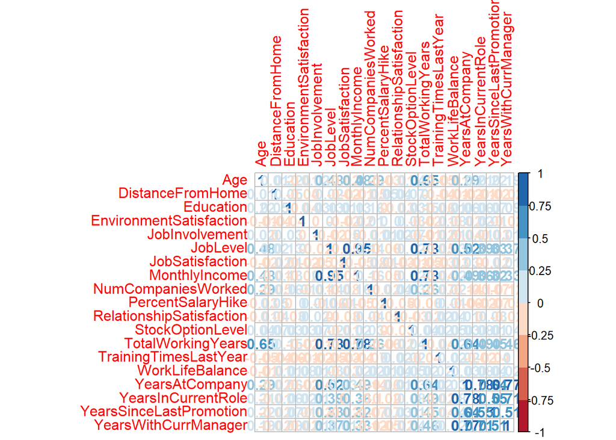

```r
corrplot(cor(case2_numeric[,numeric_varname_case2]), order = "alphabet",method="number",
         col = brewer.pal(n = 8, name = "RdBu"))
```

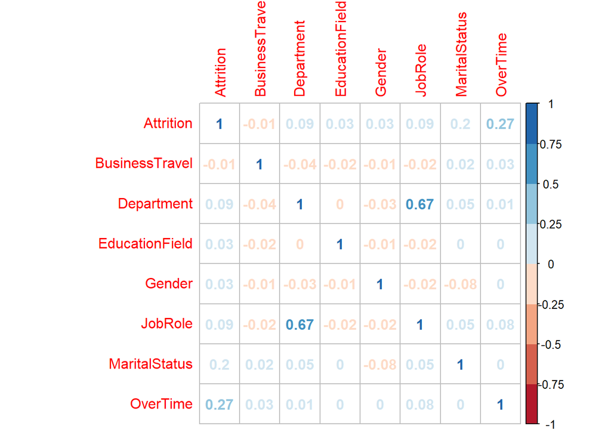

```r
corrplot(cor(case2_numeric[,char_varname_case2]), order = "alphabet",method="number",
         col = brewer.pal(n = 8, name = "RdBu"))
```

## Plot some of the numeric variables against MonthlyIncome

We observe the following:

- Evidence of a strong relationship with JobLevel
- Evidence of a moderate relationship with TotalWorkingYears
- Evidence of a moderate relationship with YearsAtCompany
- Evidence of a moderate relationship with YearsInCurrentRole

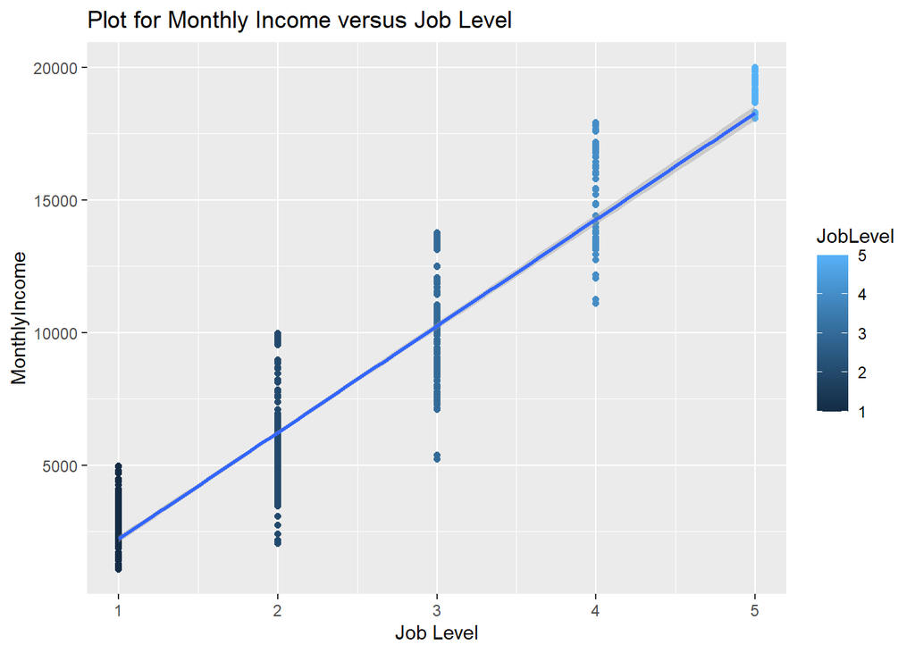

```r
ggplot(case2,aes(x=JobLevel,y=MonthlyIncome,col=JobLevel))+geom_point()+
  geom_smooth(method="lm")+
  xlab("Job Level")+ylab("MonthlyIncome")+ggtitle("Plot for Monthly Income versus Job Level")
```

```r
summary(lm(MonthlyIncome~JobLevel,data=case2))
```

```
##
## Call:
## lm(formula = MonthlyIncome ~ JobLevel, data = case2)
##
## Residuals:
##     Min      1Q  Median      3Q     Max
## -5037.1  -928.2    80.1   697.1  3723.6
##
## Coefficients:
##             Estimate Std. Error t value Pr(>|t|)
## (Intercept) -1793.93     101.68  -17.64   <2e-16 ***
## JobLevel     4013.67      43.98   91.26   <2e-16 ***
## ---
## Signif. codes:  0 '***' 0.001 '**' 0.01 '*' 0.05 '.' 0.1 ' ' 1
##
## Residual standard error: 1413 on 868 degrees of freedom
## Multiple R-squared:  0.9056, Adjusted R-squared:  0.9055
## F-statistic:  8329 on 1 and 868 DF,  p-value: < 2.2e-16
```

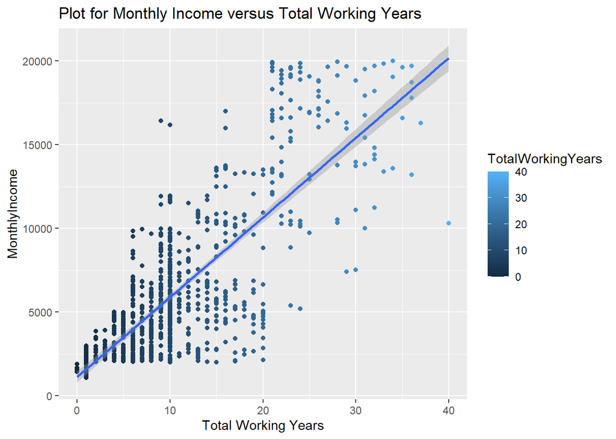

```r
ggplot(case2,aes(x=TotalWorkingYears,y=MonthlyIncome,col=TotalWorkingYears))+geom_point()+
  geom_smooth(method="lm")+
  xlab("Total Working Years")+ylab("MonthlyIncome")+ggtitle("Plot for Monthly Income versus Total Working Years")
```

```r
summary(lm(MonthlyIncome~TotalWorkingYears,data=case2))
```

```
##
## Call:
## lm(formula = MonthlyIncome ~ TotalWorkingYears, data = case2)
##
## Residuals:
##     Min      1Q  Median      3Q     Max
## -9868.1 -1703.7   -44.5  1453.1 11009.7
##
## Coefficients:
##                   Estimate Std. Error t value Pr(>|t|)
## (Intercept)        1124.90     174.19   6.458 1.77e-10 ***
## TotalWorkingYears   476.38      13.04  36.544  < 2e-16 ***
## ---
## Signif. codes:  0 '***' 0.001 '**' 0.01 '*' 0.05 '.' 0.1 ' ' 1
##
## Residual standard error: 2887 on 868 degrees of freedom
## Multiple R-squared:  0.6061, Adjusted R-squared:  0.6056
## F-statistic:  1335 on 1 and 868 DF,  p-value: < 2.2e-16
```

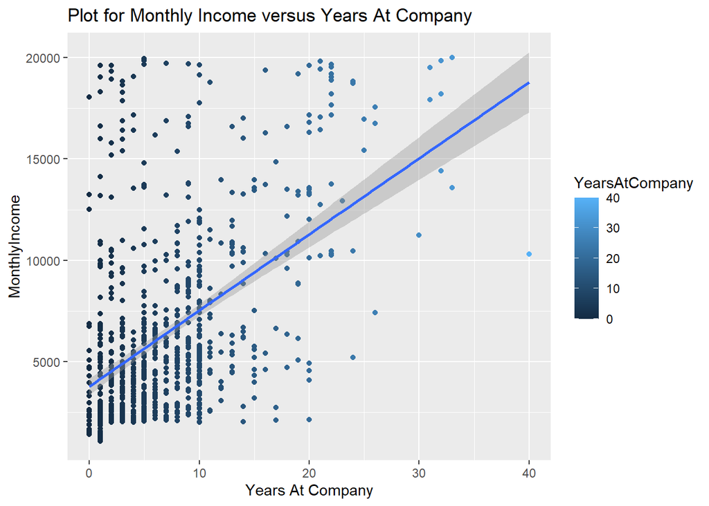

```r
ggplot(case2,aes(x=YearsAtCompany,y=MonthlyIncome,col=YearsAtCompany))+geom_point()+
  geom_smooth(method="lm")+
  xlab("Years At Company")+ylab("MonthlyIncome")+ggtitle("Plot for Monthly Income versus Years At Company")
```

```r
summary(lm(MonthlyIncome~YearsAtCompany,data=case2))
```

```
##
## Call:
## lm(formula = MonthlyIncome ~ YearsAtCompany, data = case2)
##
## Residuals:
##    Min     1Q Median     3Q    Max
##  -9149  -2458  -1198   1364  15460
##
## Coefficients:
##                Estimate Std. Error t value Pr(>|t|)
## (Intercept)     3777.96     207.73   18.19   <2e-16 ***
## YearsAtCompany   375.22      22.57   16.62   <2e-16 ***
## ---
## Signif. codes:  0 '***' 0.001 '**' 0.01 '*' 0.05 '.' 0.1 ' ' 1
##
## Residual standard error: 4007 on 868 degrees of freedom
## Multiple R-squared:  0.2415, Adjusted R-squared:  0.2406
## F-statistic: 276.3 on 1 and 868 DF,  p-value: < 2.2e-16
```

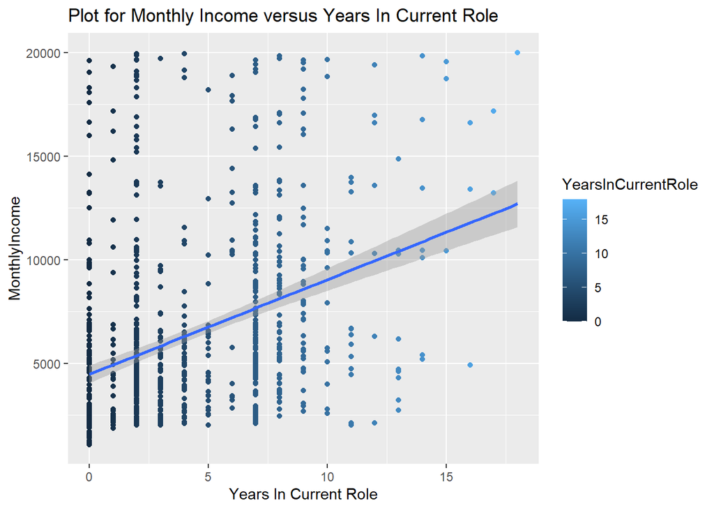

```r
ggplot(case2,aes(x=YearsInCurrentRole,y=MonthlyIncome,col=YearsInCurrentRole))+geom_point()+
  geom_smooth(method="lm")+
  xlab("Years In Current Role")+ylab("MonthlyIncome")+ggtitle("Plot for Monthly Income versus Years In Current Role")
```

```r
summary(lm(MonthlyIncome~YearsInCurrentRole,data=case2))
```

```
##
## Call:
## lm(formula = MonthlyIncome ~ YearsInCurrentRole, data = case2)
##
## Residuals:
##    Min     1Q Median     3Q    Max
##  -7839  -2755  -1377   1188  15145
##
## Coefficients:
##                    Estimate Std. Error t value Pr(>|t|)
## (Intercept)         4468.23     222.24   20.11   <2e-16 ***
## YearsInCurrentRole   457.13      39.97   11.44   <2e-16 ***
## ---
## Signif. codes:  0 '***' 0.001 '**' 0.01 '*' 0.05 '.' 0.1 ' ' 1
##
## Residual standard error: 4289 on 868 degrees of freedom
## Multiple R-squared:  0.1309, Adjusted R-squared:  0.1299
## F-statistic: 130.8 on 1 and 868 DF,  p-value: < 2.2e-16
```

## Plot for checking normality for Monthly Income and Attrition

We split the income values into separate vectors and run some exploratory analysis on them. We see that there are about 5 times as many employees who stay vs those who leave. It also appears the mean MonthlyIncome for employees who leave is somewhat lower:

- $4764.79 for employees who leave
- $6702 for those that stay

There is also greater variance in between the two groups as well: * The “Yes” group having a standard deviation of $3786.389 * The “No” group having a standard deviation of $4675.472

```r
attrition.No.monthlyIncome=case2%>%dplyr::select(Attrition,MonthlyIncome)%>%filter(Attrition=="No")
dim(attrition.No.monthlyIncome)
```

```
## [1] 730   2
```

```r
attrition.No.monthlyIncome%>%summarise(Mean=mean(attrition.No.monthlyIncome$MonthlyIncome),
                                       Median=median(attrition.No.monthlyIncome$MonthlyIncome),
                                       Standard.Deviation=sd(attrition.No.monthlyIncome$MonthlyIncome),
                                       IQR=IQR(attrition.No.monthlyIncome$MonthlyIncome))
```

```
##   Mean Median Standard.Deviation    IQR
## 1 6702 5208.5           4675.472 5574.5
```

```r
attrition.Yes.monthlyIncome=case2%>%dplyr::select(Attrition,MonthlyIncome)%>%filter(Attrition=="Yes")
dim(attrition.Yes.monthlyIncome)
```

```
## [1] 140   2
```

```r
attrition.Yes.monthlyIncome%>%summarise(Mean=mean(attrition.Yes.monthlyIncome$MonthlyIncome),
                                       Median=median(attrition.Yes.monthlyIncome$MonthlyIncome),
                                      Standard.Deviation=sd(attrition.Yes.monthlyIncome$MonthlyIncome),
                                       IQR=IQR(attrition.Yes.monthlyIncome$MonthlyIncome))
```

```
##       Mean Median Standard.Deviation     IQR
## 1 4764.786   3171           3786.389 3497.25
```

## Checking assumptions for Attrition and MonthlyIncome and doing T-test

- Visually looking at the histogram and qqplot, it seems like the Attrition data has some right skewness.
- Visually looking at the histogram and qqplot, it seems like the Attrition data has some right skewness.
- Because both distributions differ significantly from normality we log transform them in order to do a t-test and see if there is evidence that the distributions differ significantly from each other.
- The QQ Plot of the log transformed MonthlyIncome for each group shows much better adherence to normality, and brings the variance of each group much closer together.
- The T-test itself shows there is a significant difference between the Monthly Incomes of “Yes” vs “No” attrition groups, p-value < 0.0001. This is strong evidence that MonthlyIncome has an effect on Attrition

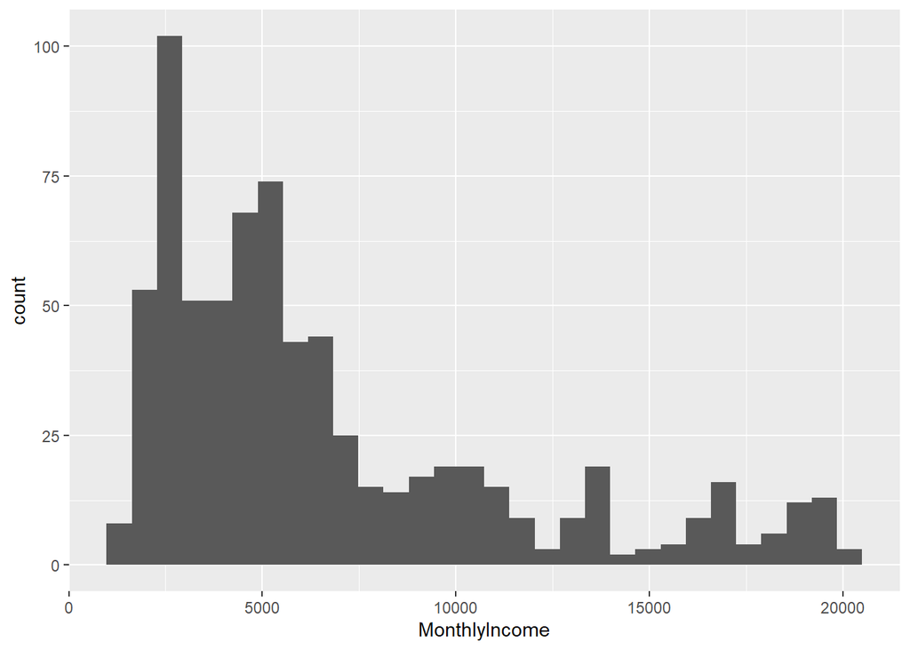

```r
ggplot(attrition.No.monthlyIncome,aes(x=MonthlyIncome))+geom_histogram()
```

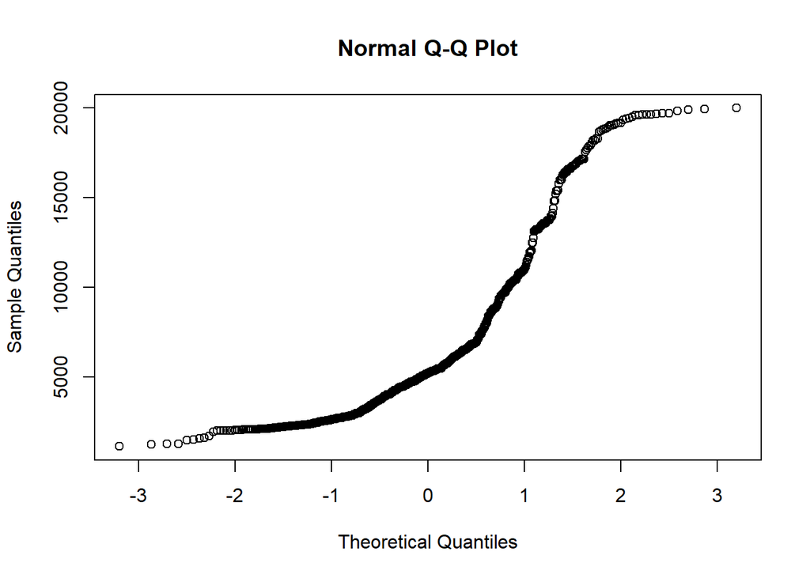

```r
qqnorm(attrition.No.monthlyIncome$MonthlyIncome)
```

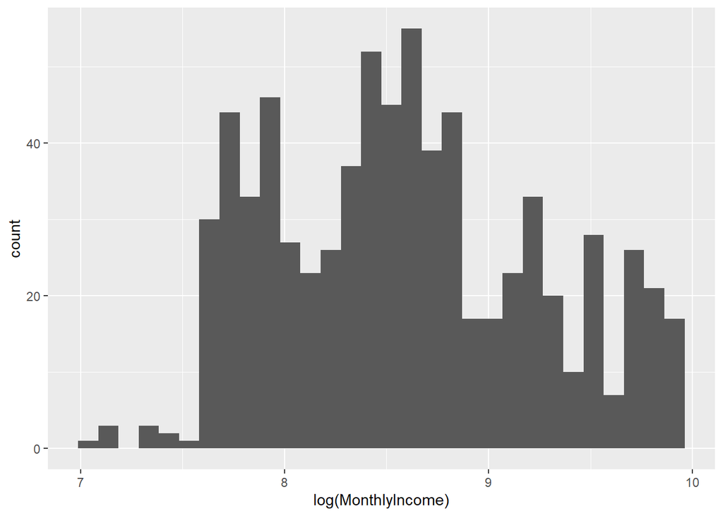

```r
ggplot(attrition.No.monthlyIncome,aes(x=log(MonthlyIncome)))+geom_histogram()
```

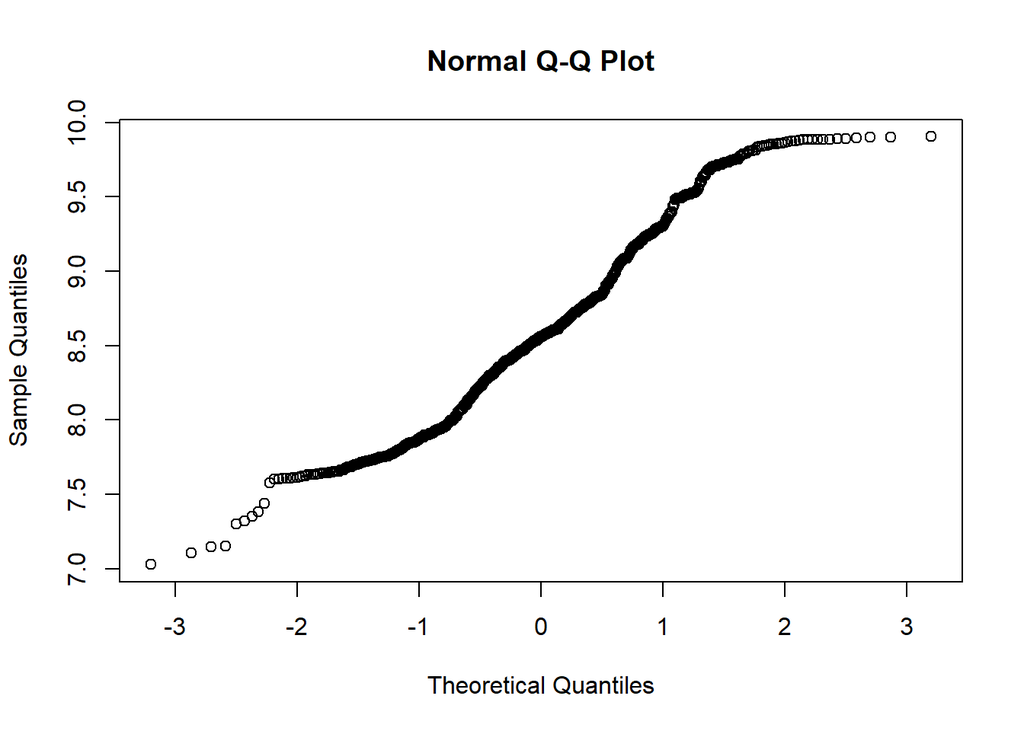

```r
qqnorm(log(attrition.No.monthlyIncome$MonthlyIncome))
```

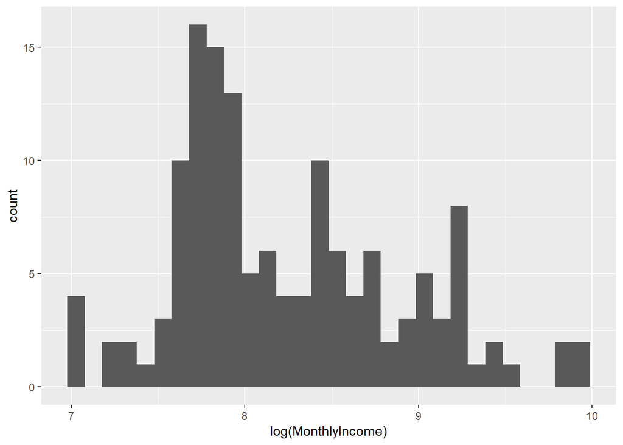

```r
ggplot(attrition.Yes.monthlyIncome,aes(x=log(MonthlyIncome)))+geom_histogram()
```

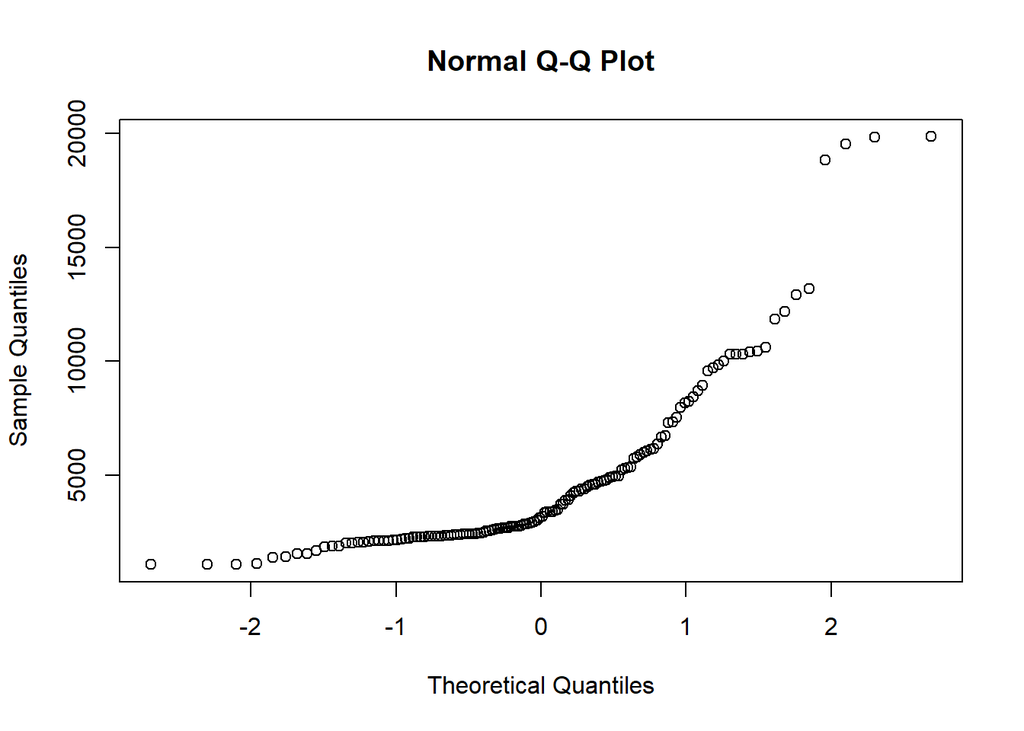

```r
qqnorm(attrition.Yes.monthlyIncome$MonthlyIncome)
```

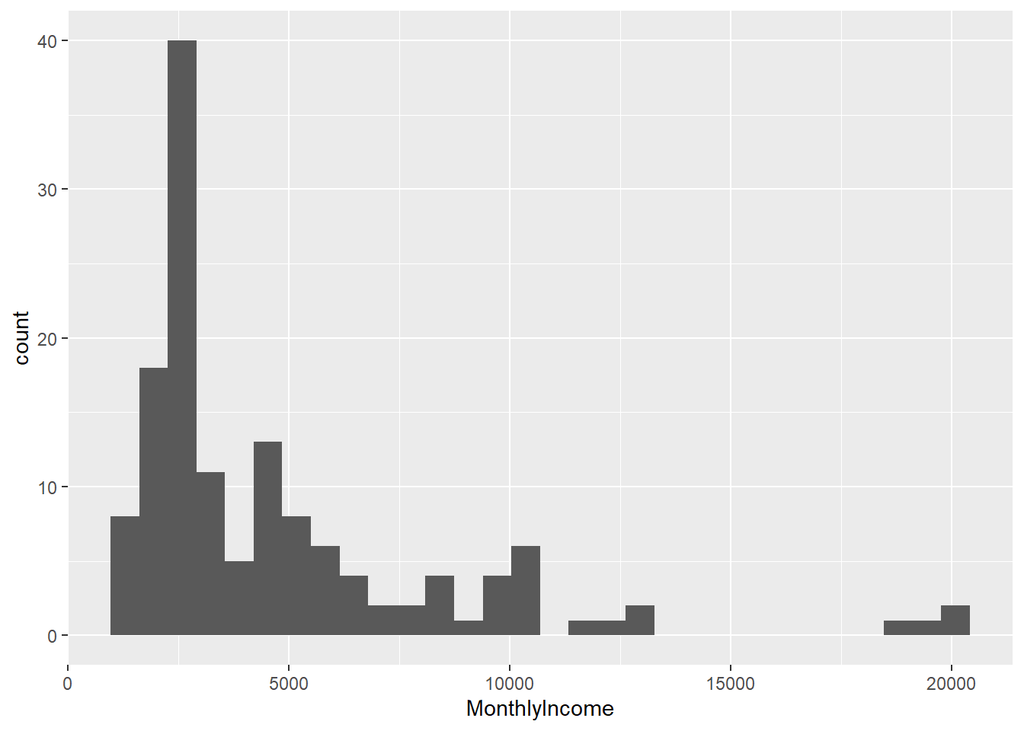

```r
ggplot(attrition.Yes.monthlyIncome,aes(x=MonthlyIncome))+geom_histogram()
```

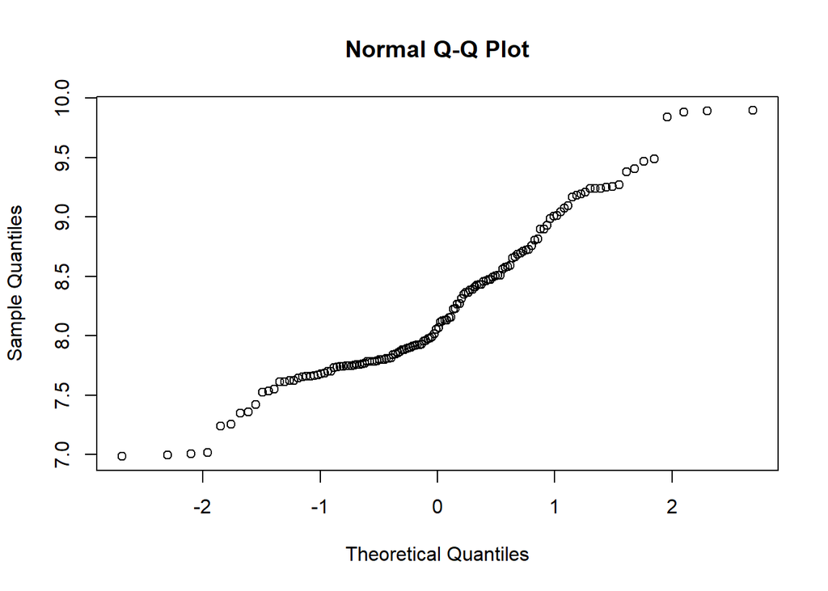

```r
qqnorm(log(attrition.Yes.monthlyIncome$MonthlyIncome))
```

```r
t.test(log(attrition.Yes.monthlyIncome$MonthlyIncome), log(attrition.No.monthlyIncome$MonthlyIncome), var.equal = F)
```

```
##
##  Welch Two Sample t-test
##
## data:  log(attrition.Yes.monthlyIncome$MonthlyIncome) and log(attrition.No.monthlyIncome$MonthlyIncome)
## t = -5.9593, df = 195.72, p-value = 1.16e-08
## alternative hypothesis: true difference in means is not equal to 0
## 95 percent confidence interval:
##  -0.4756331 -0.2391013
## sample estimates:
## mean of x mean of y
##  8.237820  8.595187
```

# Model for MonthlyIncome

## Removing the self-generated variables and Attrition from the dataframe and creating the model for Monthly income

We will create a random forest model for looking at the top influential variables among the 26 variables which leads to higher Monthly Income after removing the self-generated variables and Attrition.

*Salary*

Top 5 most influential were:

- JobLevel
- TotalWorkingYears
- JobRole
- Age
- YearsAtCompany

```r
dim(case2)
```

```
## [1] 870  29
```

```r
colnames(case2)
```

```
##  [1] "Age"                      "Attrition"
##  [3] "BusinessTravel"           "Department"
##  [5] "DistanceFromHome"         "Education"
##  [7] "EducationField"           "EnvironmentSatisfaction"
##  [9] "Gender"                   "JobInvolvement"
## [11] "JobLevel"                 "JobRole"
## [13] "JobSatisfaction"          "MaritalStatus"
## [15] "MonthlyIncome"            "NumCompaniesWorked"
## [17] "OverTime"                 "PercentSalaryHike"
## [19] "RelationshipSatisfaction" "StockOptionLevel"
## [21] "TotalWorkingYears"        "TrainingTimesLastYear"
## [23] "WorkLifeBalance"          "YearsAtCompany"
## [25] "YearsInCurrentRole"       "YearsSinceLastPromotion"
## [27] "YearsWithCurrManager"     "MonthlyIncome.categorize"
## [29] "WorkingYears"
```

```r
case2[,-c(2,28,29,30,31)] -> case2_salary
case2_salary_features <- randomForest(MonthlyIncome ~.,
                                     data = case2_salary,
 importance = TRUE)
colnames(case2_salary)
```

```
##  [1] "Age"                      "BusinessTravel"
##  [3] "Department"               "DistanceFromHome"
##  [5] "Education"                "EducationField"
##  [7] "EnvironmentSatisfaction"  "Gender"
##  [9] "JobInvolvement"           "JobLevel"
## [11] "JobRole"                  "JobSatisfaction"
## [13] "MaritalStatus"            "MonthlyIncome"
## [15] "NumCompaniesWorked"       "OverTime"
## [17] "PercentSalaryHike"        "RelationshipSatisfaction"
## [19] "StockOptionLevel"         "TotalWorkingYears"
## [21] "TrainingTimesLastYear"    "WorkLifeBalance"
## [23] "YearsAtCompany"           "YearsInCurrentRole"
## [25] "YearsSinceLastPromotion"  "YearsWithCurrManager"
```

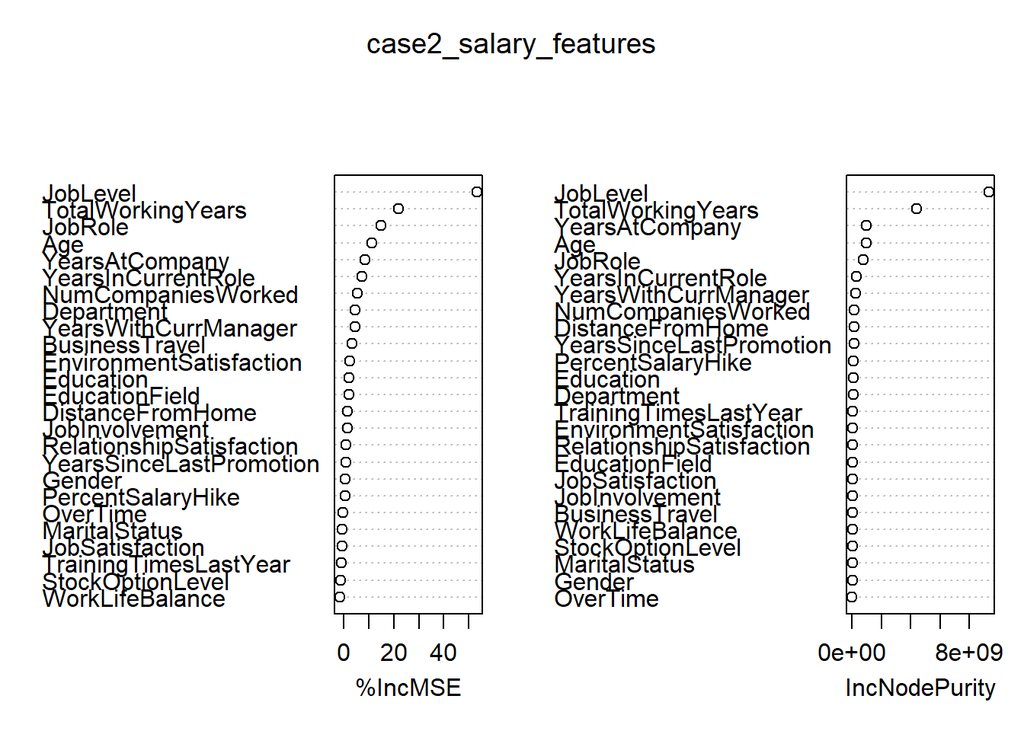

```r
varImpPlot(case2_salary_features)
```

```r
importance(case2_salary_features)
```

```
##                             %IncMSE IncNodePurity
## Age                      11.0857528     972443350
## BusinessTravel            3.1157950      40713226
## Department                4.5113469      86353082
## DistanceFromHome          1.4807044     135666771
## Education                 2.1569439      99911960
## EducationField            2.1337597      56736635
## EnvironmentSatisfaction   2.3838342      68045724
## Gender                    0.5241308      27603933
## JobInvolvement            1.3171919      45518230
## JobLevel                 53.2567540    9333132250
## JobRole                  14.8413057     792715632
## JobSatisfaction          -0.6946743      54695253
## MaritalStatus            -0.6910330      31572882
## NumCompaniesWorked        5.3199157     153319007
## OverTime                 -0.4636848      19167977
## PercentSalaryHike         0.3584063     110735099
## RelationshipSatisfaction  0.9433335      57390478
## StockOptionLevel         -1.3437983      37313389
## TotalWorkingYears        21.8264099    4416245585
## TrainingTimesLastYear    -0.9261275      70408365
## WorkLifeBalance          -1.6074484      39330035
## YearsAtCompany            8.4683730     978300464
## YearsInCurrentRole        7.2926961     293073817
## YearsSinceLastPromotion   0.7658527     130437075
## YearsWithCurrManager      4.4494306     234098322
```

## Looking at Top 5 infuential variables correlation with MonthlyIncome

Looking at the correlation plot for the top 5 influential factors that leads to higher monthly income.

```r
income.totalYears=data.frame(TotalWorkingYears=case2$TotalWorkingYears,MonthlyIncome=case2$MonthlyIncome,
                             JobRole=case2_numeric$JobRole,JobLevel=case2$JobLevel,
                             Age=case2$Age,YearsAtCompany=case2$YearsAtCompany)
dim(income.totalYears)
```

```
## [1] 870   6
```

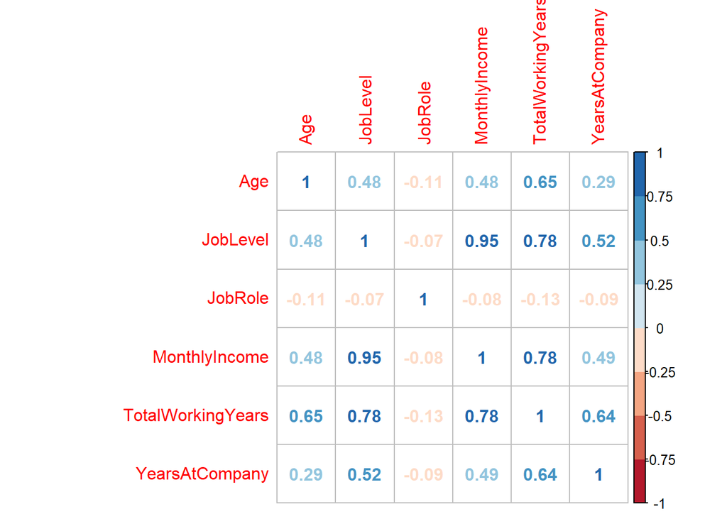

```r
corrplot(cor(income.totalYears), order = "alphabet",
         col = brewer.pal(n = 8, name = "RdBu"),method="number")
```

## PLot for Job Level by Monthly Income

We have plotted the bar graph to see the monthly income of employees based on their job level in the company.

- Visually looking at the graph it seems like the all employees at Job Level=1 have the earning less than 5000.
- With job level=1, approximately 37.81% of all the employees at the company are earning less than 5000.
- Approximately 97.24% of the employees having income under 2500 are at Job Level=1
- Only 15.67% of the employees earning above 7500 are at Job Level=5. No employees at job level=5 are earning below 7500.

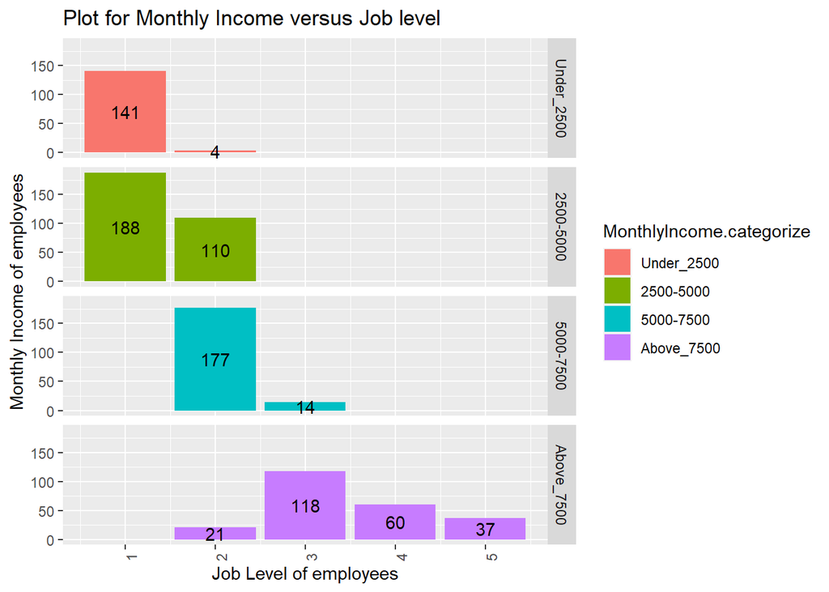

```r
ggplot(case2,aes(x=JobLevel,fill=MonthlyIncome.categorize))+geom_bar(position="stack",stat="count")+
  theme(axis.text.x = element_text(angle = 90))+geom_text(aes(label=..count..),stat="count",position=position_stack(0.5))+facet_grid(row=vars(MonthlyIncome.categorize))+
  xlab("Job Level of employees")+ylab("Monthly Income of employees")+ggtitle("Plot for Monthly Income versus Job level")
```

```r
colnames(case2)
```

```
##  [1] "Age"                      "Attrition"
##  [3] "BusinessTravel"           "Department"
##  [5] "DistanceFromHome"         "Education"
##  [7] "EducationField"           "EnvironmentSatisfaction"
##  [9] "Gender"                   "JobInvolvement"
## [11] "JobLevel"                 "JobRole"
## [13] "JobSatisfaction"          "MaritalStatus"
## [15] "MonthlyIncome"            "NumCompaniesWorked"
## [17] "OverTime"                 "PercentSalaryHike"
## [19] "RelationshipSatisfaction" "StockOptionLevel"
## [21] "TotalWorkingYears"        "TrainingTimesLastYear"
## [23] "WorkLifeBalance"          "YearsAtCompany"
## [25] "YearsInCurrentRole"       "YearsSinceLastPromotion"
## [27] "YearsWithCurrManager"     "MonthlyIncome.categorize"
## [29] "WorkingYears"
```

## Plot for Monthly Income by Total Working Years

We have plotted the bar graph to see the monthly income of employees based on their total working years in the company.

- We found that only 10.59% of the employees earning above 7500 are working in the company for more than 30 years. None of the employees working for more than 30 years have income less than 7500.
- We also found that none of the employees are earning above 5000 who have been working less than 5 years in the company.

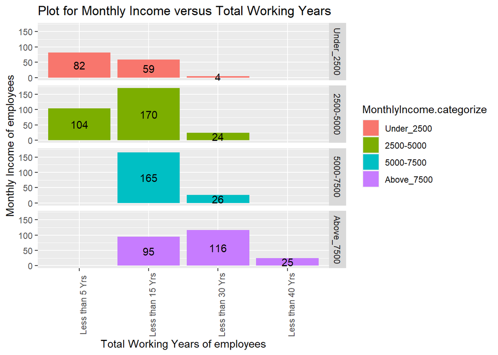

```r
ggplot(case2,aes(fill=MonthlyIncome.categorize,x=WorkingYears))+geom_bar(position="stack",stat="count",na.rm = TRUE)+
  facet_grid(row=vars(MonthlyIncome.categorize))+
  theme(axis.text.x = element_text(angle = 90))+geom_text(aes(label=..count..),stat="count",position=position_stack(0.5))+
    xlab("Total Working Years of employees")+ylab("Monthly Income of employees")+ggtitle("Plot for Monthly Income versus Total Working Years")
```

## Plot for Monthly Income by Job Role

We have plotted the bar graph to see the Monthly income of employees based on their job role in the company.

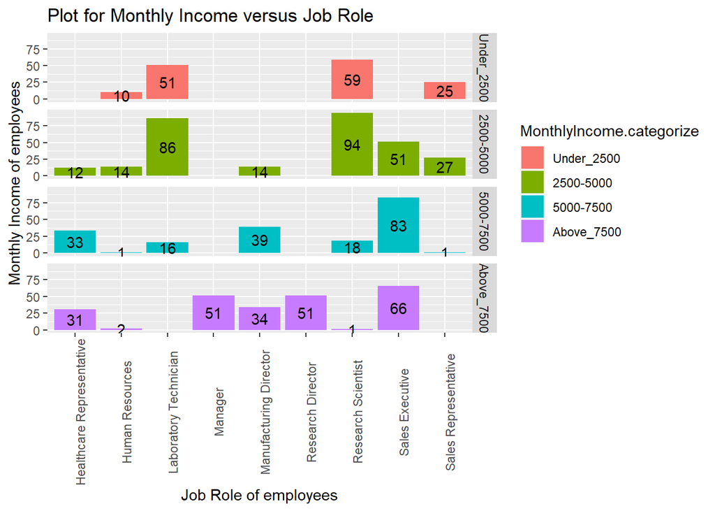

```r
ggplot(case2,aes(fill=MonthlyIncome.categorize,x=JobRole))+geom_bar(position="stack",stat="count",na.rm = TRUE)+
 facet_grid(row=vars(MonthlyIncome.categorize))+
  theme(axis.text.x = element_text(angle = 90))+geom_text(aes(label=..count..),stat="count",position=position_stack(0.5))+
 xlab("Job Role of employees")+ylab("Monthly Income of employees")+ggtitle("Plot for Monthly Income versus Job Role")
```

## Plot for Years At Company by MonthlyIncome

Visually looking at the graph it seems like the more than 50% of the total employees are working at the comapny for less than 5 years.

Approximately 27.19% of the employees working at the company for less than 5 years are likely to earn below 2500.

Only 3.38% of the employees earning above 7500 are working at the company for more than 30 years.

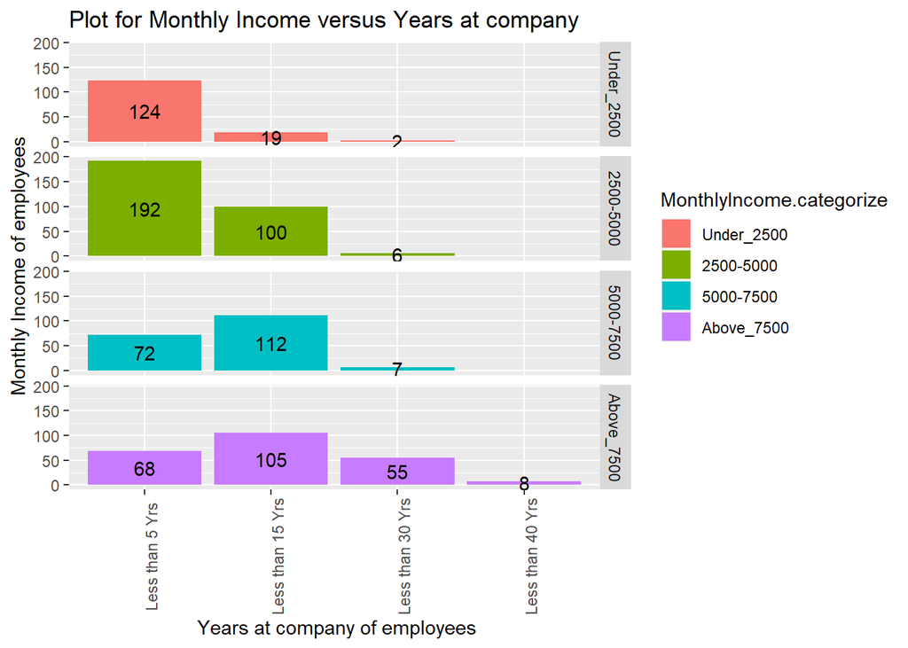

```r
case2$CompanyYears=cut(case2$YearsAtCompany,
        breaks = c(-1,5,15,30,100),
  labels = c("Less than 5 Yrs","Less than 15 Yrs","Less than 30 Yrs","Less than 40 Yrs")
 )
ggplot(case2,aes(fill=MonthlyIncome.categorize,x=CompanyYears))+geom_bar(position="stack",stat="count",na.rm = TRUE)+
  theme(axis.text.x = element_text(angle=90))+geom_text(aes(label=..count..),stat="count",position=position_stack(0.5))+
facet_grid(row=vars(MonthlyIncome.categorize))+
  xlab(" Years at company of employees")+ylab("Monthly Income of employees")+ggtitle("Plot for Monthly Income versus Years at company")
```

## Plot for Age by Monthly Income

Only 7.65% of the employees having 19 to 30 years age earn above 7500 and approximately 31.53% of the employees earn below 2500.

We found that 57.33% of the employees having age 50 to 60 years are earning above 7500.

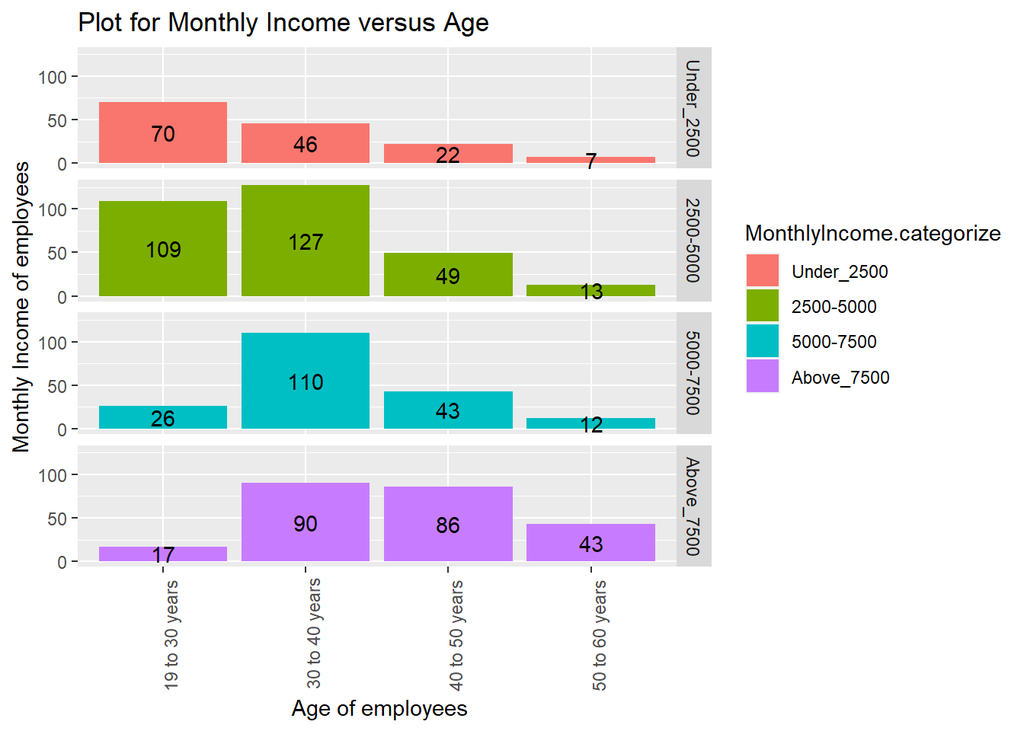

```r
case2$AgeEmp=cut(case2$Age,
        breaks = c(17,30,40,50,60,100),
  labels = c("19 to 30 years"," 30 to 40 years","40 to 50 years","50 to 60 years","Above 60 years")
 )
ggplot(case2,aes(fill=MonthlyIncome.categorize,x=AgeEmp))+geom_bar(position="stack",stat="count",na.rm = TRUE)+
  theme(axis.text.x = element_text(angle=90))+geom_text(aes(label=..count..),stat="count",position=position_stack(0.5))+
facet_grid(row=vars(MonthlyIncome.categorize))+ xlab(" Age of employees")+ylab("Monthly Income of employees")+ggtitle("Plot for Monthly Income versus Age")
```

```r
colnames(case2)
```

```
##  [1] "Age"                      "Attrition"
##  [3] "BusinessTravel"           "Department"
##  [5] "DistanceFromHome"         "Education"
##  [7] "EducationField"           "EnvironmentSatisfaction"
##  [9] "Gender"                   "JobInvolvement"
## [11] "JobLevel"                 "JobRole"
## [13] "JobSatisfaction"          "MaritalStatus"
## [15] "MonthlyIncome"            "NumCompaniesWorked"
## [17] "OverTime"                 "PercentSalaryHike"
## [19] "RelationshipSatisfaction" "StockOptionLevel"
## [21] "TotalWorkingYears"        "TrainingTimesLastYear"
## [23] "WorkLifeBalance"          "YearsAtCompany"
## [25] "YearsInCurrentRole"       "YearsSinceLastPromotion"
## [27] "YearsWithCurrManager"     "MonthlyIncome.categorize"
## [29] "WorkingYears"             "CompanyYears"
## [31] "AgeEmp"
```

## Building a linear regression model for Monthly income vs all variables

- By building the linear regression model we found the following:
- R-squared=0.9491; that means the the model is capable of explaining that 94.91% of the monthly income is associated with all the factors given in the data.

Then looking at the variation inflation factor, we see that the department and job role variables are having VIF higher than 10, so in the next step we will remove these two variables.

```r
case2_salary -> case2_salary_reg
# First create model on all variables
lm(MonthlyIncome ~ ., data =  case2_salary_reg) -> case2_salary_lm
summary(case2_salary_lm)
```

```
##
## Call:
## lm(formula = MonthlyIncome ~ ., data = case2_salary_reg)
##
## Residuals:
##     Min      1Q  Median      3Q     Max
## -3737.2  -656.2   -33.6   589.1  4136.7
##
## Coefficients:
##                                  Estimate Std. Error t value Pr(>|t|)
## (Intercept)                      -606.140    668.262  -0.907 0.364649
## Age                                -1.639      5.654  -0.290 0.771955
## BusinessTravelTravel_Frequently   182.855    141.863   1.289 0.197775
## BusinessTravelTravel_Rarely       369.777    120.413   3.071 0.002204 **
## DepartmentResearch & Development  114.497    478.229   0.239 0.810839
## DepartmentSales                  -430.542    489.251  -0.880 0.379113
## DistanceFromHome                   -6.311      4.559  -1.384 0.166647
## Education                         -30.058     37.243  -0.807 0.419856
## EducationFieldLife Sciences       131.421    369.673   0.356 0.722301
## EducationFieldMarketing           106.003    391.782   0.271 0.786792
## EducationFieldMedical              26.071    370.560   0.070 0.943927
## EducationFieldOther                84.344    395.567   0.213 0.831205
## EducationFieldTechnical Degree     87.267    385.419   0.226 0.820930
## EnvironmentSatisfaction           -10.055     33.561  -0.300 0.764551
## GenderMale                        119.237     74.663   1.597 0.110648
## JobInvolvement                     17.245     52.444   0.329 0.742365
## JobLevel                         2798.801     83.435  33.544  < 2e-16 ***
## JobRoleHuman Resources           -191.727    516.673  -0.371 0.710673
## JobRoleLaboratory Technician     -603.937    171.759  -3.516 0.000462 ***
## JobRoleManager                   4199.953    282.586  14.863  < 2e-16 ***
## JobRoleManufacturing Director     153.533    170.023   0.903 0.366782
## JobRoleResearch Director         4012.539    219.451  18.284  < 2e-16 ***
## JobRoleResearch Scientist        -331.361    170.699  -1.941 0.052572 .
## JobRoleSales Executive            487.672    358.943   1.359 0.174632
## JobRoleSales Representative       109.404    392.699   0.279 0.780625
## JobSatisfaction                    23.515     32.974   0.713 0.475958
## MaritalStatusMarried               70.239    100.024   0.702 0.482740
## MaritalStatusSingle                16.787    134.568   0.125 0.900753
## NumCompaniesWorked                  8.757     16.798   0.521 0.602279
## OverTimeYes                         7.519     81.140   0.093 0.926191
## PercentSalaryHike                   1.193      9.961   0.120 0.904732
## RelationshipSatisfaction           16.304     33.297   0.490 0.624510
## StockOptionLevel                    6.157     56.901   0.108 0.913859
## TotalWorkingYears                  49.926     10.999   4.539 6.48e-06 ***
## TrainingTimesLastYear              23.730     29.182   0.813 0.416350
## WorkLifeBalance                   -43.459     51.593  -0.842 0.399844
## YearsAtCompany                     -2.131     13.620  -0.156 0.875706
## YearsInCurrentRole                  3.479     17.006   0.205 0.837942
## YearsSinceLastPromotion            29.344     15.258   1.923 0.054804 .
## YearsWithCurrManager              -26.775     16.731  -1.600 0.109901
## ---
## Signif. codes:  0 '***' 0.001 '**' 0.01 '*' 0.05 '.' 0.1 ' ' 1
##
## Residual standard error: 1061 on 830 degrees of freedom
## Multiple R-squared:  0.9491, Adjusted R-squared:  0.9468
## F-statistic: 397.2 on 39 and 830 DF,  p-value: < 2.2e-16
```

```r
# Then test for VIF
vif(case2_salary_lm)
```

```
##                                GVIF Df GVIF^(1/(2*Df))
## Age                        1.966832  1        1.402438
## BusinessTravel             1.110032  2        1.026441
## Department               110.874985  2        3.244953
## DistanceFromHome           1.062561  1        1.030806
## Education                  1.120870  1        1.058711
## EducationField             2.898610  5        1.112292
## EnvironmentSatisfaction    1.051126  1        1.025244
## Gender                     1.039965  1        1.019787
## JobInvolvement             1.051408  1        1.025382
## JobLevel                   6.387536  1        2.527358
## JobRole                  494.745698  8        1.473665
## JobSatisfaction            1.042825  1        1.021188
## MaritalStatus              1.984091  2        1.186835
## NumCompaniesWorked         1.384089  1        1.176473
## OverTime                   1.047147  1        1.023302
## PercentSalaryHike          1.034879  1        1.017290
## RelationshipSatisfaction   1.040543  1        1.020070
## StockOptionLevel           1.839351  1        1.356227
## TotalWorkingYears          5.273175  1        2.296339
## TrainingTimesLastYear      1.064991  1        1.031984
## WorkLifeBalance            1.041859  1        1.020715
## YearsAtCompany             5.192457  1        2.278696
## YearsInCurrentRole         2.957481  1        1.719733
## YearsSinceLastPromotion    1.824576  1        1.350768
## YearsWithCurrManager       2.761474  1        1.661768
```

## Removing the department and job role variables and then looking the performace of the model

By building the other linear regression model after removing the variables with high VIF, we found the following:

- R-squared=0.9142; that means the the model is capable of explaining that 91.42% of the monthly income is associated with all the factors given in the data.

```r
case2_salary_reg[,-c(3,11)] -> case2_salary_reg.df
# create model on remaining variables
lm(MonthlyIncome ~ ., data =  case2_salary_reg.df) -> case2_salary_lm
summary(case2_salary_lm)
```

```
##
## Call:
## lm(formula = MonthlyIncome ~ ., data = case2_salary_reg.df)
##
## Residuals:
##     Min      1Q  Median      3Q     Max
## -5887.4  -773.2    -5.9   737.8  4298.4
##
## Coefficients:
##                                  Estimate Std. Error t value Pr(>|t|)
## (Intercept)                     -1782.451    620.768  -2.871  0.00419 **
## Age                                -2.495      7.248  -0.344  0.73078
## BusinessTravelTravel_Frequently    10.519    181.412   0.058  0.95378
## BusinessTravelTravel_Rarely       320.016    154.308   2.074  0.03840 *
## DistanceFromHome                  -15.799      5.852  -2.700  0.00707 **
## Education                          15.477     47.543   0.326  0.74486
## EducationFieldLife Sciences      -309.505    364.944  -0.848  0.39663
## EducationFieldMarketing          -672.812    383.954  -1.752  0.08008 .
## EducationFieldMedical            -270.299    367.359  -0.736  0.46206
## EducationFieldOther              -387.162    405.311  -0.955  0.33974
## EducationFieldTechnical Degree   -312.110    391.375  -0.797  0.42540
## EnvironmentSatisfaction           -64.796     42.881  -1.511  0.13115
## GenderMale                         76.079     95.943   0.793  0.42803
## JobInvolvement                     91.904     67.057   1.371  0.17089
## JobLevel                         3747.315     69.837  53.658  < 2e-16 ***
## JobSatisfaction                    -1.963     42.486  -0.046  0.96316
## MaritalStatusMarried              149.809    128.232   1.168  0.24303
## MaritalStatusSingle                -9.188    172.030  -0.053  0.95742
## NumCompaniesWorked                -11.593     21.527  -0.539  0.59034
## OverTimeYes                        27.770    103.798   0.268  0.78912
## PercentSalaryHike                   9.278     12.808   0.724  0.46902
## RelationshipSatisfaction           24.974     42.911   0.582  0.56073
## StockOptionLevel                  -11.084     73.068  -0.152  0.87946
## TotalWorkingYears                  70.850     13.887   5.102 4.16e-07 ***
## TrainingTimesLastYear              22.175     37.356   0.594  0.55294
## WorkLifeBalance                   -28.164     66.264  -0.425  0.67093
## YearsAtCompany                    -10.388     17.366  -0.598  0.54989
## YearsInCurrentRole                -11.438     21.680  -0.528  0.59791
## YearsSinceLastPromotion             7.041     19.534   0.360  0.71862
## YearsWithCurrManager              -44.929     21.373  -2.102  0.03584 *
## ---
## Signif. codes:  0 '***' 0.001 '**' 0.01 '*' 0.05 '.' 0.1 ' ' 1
##
## Residual standard error: 1370 on 840 degrees of freedom
## Multiple R-squared:  0.9142, Adjusted R-squared:  0.9112
## F-statistic: 308.5 on 29 and 840 DF,  p-value: < 2.2e-16
```

```r
# Then test for VIF
vif(case2_salary_lm)
```

```
##                              GVIF Df GVIF^(1/(2*Df))
## Age                      1.937665  1        1.392000
## BusinessTravel           1.071643  2        1.017449
## DistanceFromHome         1.049644  1        1.024522
## Education                1.095339  1        1.046584
## EducationField           1.157371  5        1.014722
## EnvironmentSatisfaction  1.028985  1        1.014389
## Gender                   1.029746  1        1.014764
## JobInvolvement           1.030792  1        1.015279
## JobLevel                 2.683566  1        1.638159
## JobSatisfaction          1.038164  1        1.018903
## MaritalStatus            1.931779  2        1.178934
## NumCompaniesWorked       1.363027  1        1.167488
## OverTime                 1.027599  1        1.013705
## PercentSalaryHike        1.026095  1        1.012964
## RelationshipSatisfaction 1.036300  1        1.017988
## StockOptionLevel         1.818774  1        1.348619
## TotalWorkingYears        5.040957  1        2.245208
## TrainingTimesLastYear    1.046526  1        1.022999
## WorkLifeBalance          1.030572  1        1.015171
## YearsAtCompany           5.062406  1        2.249979
## YearsInCurrentRole       2.882311  1        1.697737
## YearsSinceLastPromotion  1.793276  1        1.339133
## YearsWithCurrManager     2.702426  1        1.643906
```

```r
case2_salary_reg.df[,-c(17,20)] -> case2_salary_reg.df
# create model on remaining variables
lm(MonthlyIncome ~ ., data =  case2_salary_reg.df) -> case2_salary_lm
summary(case2_salary_lm)
```

```
##
## Call:
## lm(formula = MonthlyIncome ~ ., data = case2_salary_reg.df)
##
## Residuals:
##     Min      1Q  Median      3Q     Max
## -5899.5  -766.7    -4.8   737.7  4293.3
##
## Coefficients:
##                                  Estimate Std. Error t value Pr(>|t|)
## (Intercept)                     -1874.727    586.219  -3.198  0.00144 **
## Age                                -2.356      7.231  -0.326  0.74466
## BusinessTravelTravel_Frequently     9.868    181.145   0.054  0.95657
## BusinessTravelTravel_Rarely       321.165    154.100   2.084  0.03745 *
## DistanceFromHome                  -15.818      5.836  -2.711  0.00685 **
## Education                          15.064     47.474   0.317  0.75109
## EducationFieldLife Sciences      -304.671    364.293  -0.836  0.40320
## EducationFieldMarketing          -670.452    383.394  -1.749  0.08070 .
## EducationFieldMedical            -265.549    366.736  -0.724  0.46921
## EducationFieldOther              -382.144    404.637  -0.944  0.34523
## EducationFieldTechnical Degree   -309.825    390.918  -0.793  0.42826
## EnvironmentSatisfaction           -66.308     42.708  -1.553  0.12089
## GenderMale                         77.232     95.804   0.806  0.42039
## JobInvolvement                     91.447     66.963   1.366  0.17242
## JobLevel                         3747.049     69.706  53.755  < 2e-16 ***
## JobSatisfaction                    -1.911     42.405  -0.045  0.96407
## MaritalStatusMarried              156.815    121.956   1.286  0.19885
## MaritalStatusSingle                 8.292    132.078   0.063  0.94995
## NumCompaniesWorked                -12.014     21.469  -0.560  0.57590
## OverTimeYes                        27.813    103.687   0.268  0.78858
## PercentSalaryHike                   9.214     12.793   0.720  0.47159
## RelationshipSatisfaction           24.483     42.841   0.571  0.56782
## TotalWorkingYears                  70.856     13.871   5.108 4.03e-07 ***
## TrainingTimesLastYear              21.487     37.269   0.577  0.56441
## YearsAtCompany                    -10.095     17.330  -0.583  0.56037
## YearsInCurrentRole                -12.475     21.532  -0.579  0.56250
## YearsSinceLastPromotion             6.959     19.503   0.357  0.72131
## YearsWithCurrManager              -44.752     21.320  -2.099  0.03611 *
## ---
## Signif. codes:  0 '***' 0.001 '**' 0.01 '*' 0.05 '.' 0.1 ' ' 1
##
## Residual standard error: 1369 on 842 degrees of freedom
## Multiple R-squared:  0.9142, Adjusted R-squared:  0.9114
## F-statistic: 332.1 on 27 and 842 DF,  p-value: < 2.2e-16
```

```r
# Then test for VIF
vif(case2_salary_lm)
```

```
##                              GVIF Df GVIF^(1/(2*Df))
## Age                      1.932720  1        1.390223
## BusinessTravel           1.069613  2        1.016966
## DistanceFromHome         1.046096  1        1.022788
## Education                1.094511  1        1.046189
## EducationField           1.143749  5        1.013522
## EnvironmentSatisfaction  1.022882  1        1.011376
## Gender                   1.028956  1        1.014374
## JobInvolvement           1.030104  1        1.014941
## JobLevel                 2.679161  1        1.636814
## JobSatisfaction          1.036400  1        1.018037
## MaritalStatus            1.100055  2        1.024126
## NumCompaniesWorked       1.358563  1        1.165574
## OverTime                 1.027584  1        1.013698
## PercentSalaryHike        1.025840  1        1.012838
## RelationshipSatisfaction 1.035095  1        1.017396
## TotalWorkingYears        5.040420  1        2.245088
## TrainingTimesLastYear    1.043864  1        1.021697
## YearsAtCompany           5.051709  1        2.247601
## YearsInCurrentRole       2.849282  1        1.687982
## YearsSinceLastPromotion  1.791245  1        1.338374
## YearsWithCurrManager     2.694799  1        1.641584
```

## Using StepWise Selection for feature selection

Now that we have used multicollinearity to reduce to 22 parameters, we now will run Stepwise Feature Selection to find the 6 most influential variables and compare them to both what the Random Forest found as well as the prior Linear Regression.

Important Factors that all have p-value <= 0.05:

- BusinessTravel: Travel_Rarely
- DistanceFromHome
- EducationField: Marketing
- JobLevel
- TotalWorkingYears
- YearsWithCurrManager

```r
dim(case2_salary_reg.df)
```

```
## [1] 870  22
```

```r
trainControl(method = "cv", number = 5) -> train.CV

train(MonthlyIncome ~ .,
  data = case2_salary_reg.df,
  method = "lmStepAIC",
  trControl = train.CV
) -> case2.salary.stepwise
```

```
## Start:  AIC=10081.8
## .outcome ~ Age + BusinessTravelTravel_Frequently + BusinessTravelTravel_Rarely +
##     DistanceFromHome + Education + `EducationFieldLife Sciences` +
##     EducationFieldMarketing + EducationFieldMedical + EducationFieldOther +
##     `EducationFieldTechnical Degree` + EnvironmentSatisfaction +
##     GenderMale + JobInvolvement + JobLevel + JobSatisfaction +
##     MaritalStatusMarried + MaritalStatusSingle + NumCompaniesWorked +
##     OverTimeYes + PercentSalaryHike + RelationshipSatisfaction +
##     TotalWorkingYears + TrainingTimesLastYear + YearsAtCompany +
##     YearsInCurrentRole + YearsSinceLastPromotion + YearsWithCurrManager
##
##                                    Df  Sum of Sq        RSS   AIC
## - TrainingTimesLastYear             1        404 1254794409 10080
## - MaritalStatusSingle               1       2977 1254796982 10080
## - PercentSalaryHike                 1      27822 1254821828 10080
## - GenderMale                        1      76771 1254870776 10080
## - `EducationFieldTechnical Degree`  1     118670 1254912675 10080
## - OverTimeYes                       1     175591 1254969596 10080
## - YearsInCurrentRole                1     205124 1254999130 10080
## - YearsSinceLastPromotion           1     251573 1255045578 10080
## - Age                               1     273373 1255067379 10080
## - NumCompaniesWorked                1     282937 1255076942 10080
## - `EducationFieldLife Sciences`     1     286405 1255080411 10080
## - BusinessTravelTravel_Frequently   1     406030 1255200035 10080
## - JobSatisfaction                   1     423540 1255217545 10080
## - EducationFieldOther               1     448837 1255242842 10080
## - MaritalStatusMarried              1     649134 1255443139 10080
## - EducationFieldMedical             1     658775 1255452780 10080
## - RelationshipSatisfaction          1     867471 1255661477 10080
## - JobInvolvement                    1    1290264 1256084270 10080
## - Education                         1    1730794 1256524799 10081
## - YearsAtCompany                    1    1974501 1256768507 10081
## - YearsWithCurrManager              1    2007568 1256801573 10081
## - EducationFieldMarketing           1    3556462 1258350467 10082
## <none>                                           1254794005 10082
## - EnvironmentSatisfaction           1    5657715 1260451720 10083
## - BusinessTravelTravel_Rarely       1   13773357 1268567362 10087
## - DistanceFromHome                  1   17057065 1271851070 10089
## - TotalWorkingYears                 1   24506512 1279300518 10093
## - JobLevel                          1 4543845554 5798639559 11145
```

[output cut: 3339 more lines]

```
## .outcome ~ BusinessTravelTravel_Rarely + DistanceFromHome + EducationFieldMarketing +
##     EnvironmentSatisfaction + JobInvolvement + JobLevel + MaritalStatusMarried +
##     TotalWorkingYears + YearsWithCurrManager
##
##                               Df  Sum of Sq        RSS   AIC
## <none>                                      1585015846 12561
## - JobInvolvement               1    3932348 1588948194 12562
## - MaritalStatusMarried         1    3970026 1588985873 12562
## - EnvironmentSatisfaction      1    4979154 1589995000 12562
## - DistanceFromHome             1   12838996 1597854842 12566
## - EducationFieldMarketing      1   12878775 1597894622 12566
## - BusinessTravelTravel_Rarely  1   16737293 1601753139 12568
## - YearsWithCurrManager         1   29408237 1614424083 12575
## - TotalWorkingYears            1   70832125 1655847971 12597
## - JobLevel                     1 5548821138 7133836984 13868
```

```r
# Final model
summary(case2.salary.stepwise)
```

```
##
## Call:
## lm(formula = .outcome ~ BusinessTravelTravel_Rarely + DistanceFromHome +
##     EducationFieldMarketing + EnvironmentSatisfaction + JobInvolvement +
##     JobLevel + MaritalStatusMarried + TotalWorkingYears + YearsWithCurrManager,
##     data = dat)
##
## Residuals:
##     Min      1Q  Median      3Q     Max
## -5857.8  -761.3     0.4   735.0  4244.8
##
## Coefficients:
##                              Estimate Std. Error t value Pr(>|t|)
## (Intercept)                 -1887.027    253.357  -7.448 2.30e-13 ***
## BusinessTravelTravel_Rarely   308.194    102.270   3.014  0.00266 **
## DistanceFromHome              -15.086      5.716  -2.639  0.00846 **
## EducationFieldMarketing      -385.885    145.978  -2.643  0.00836 **
## EnvironmentSatisfaction       -68.977     41.965  -1.644  0.10061
## JobInvolvement                 95.713     65.526   1.461  0.14447
## JobLevel                     3745.203     68.256  54.870  < 2e-16 ***
## MaritalStatusMarried          137.169     93.461   1.468  0.14256
## TotalWorkingYears              64.114     10.342   6.199 8.79e-10 ***
## YearsWithCurrManager          -58.150     14.557  -3.995 7.04e-05 ***
## ---
## Signif. codes:  0 '***' 0.001 '**' 0.01 '*' 0.05 '.' 0.1 ' ' 1
##
## Residual standard error: 1358 on 860 degrees of freedom
## Multiple R-squared:  0.9137, Adjusted R-squared:  0.9128
## F-statistic:  1012 on 9 and 860 DF,  p-value: < 2.2e-16
```

```r
# Results including RMSE of final model
case2.salary.stepwise$results
```

```
##   parameter     RMSE  Rsquared      MAE   RMSESD RsquaredSD   MAESD
## 1      none 1389.265 0.9097122 1049.818 46.72613 0.00780889 46.3468
```

## Buliding a Random Forest model and Comparing to Linear Regression Model

We will the variables that were selected by random forest feature selection to build the model.

```r
train(MonthlyIncome ~ JobLevel + JobRole + TotalWorkingYears + YearsAtCompany + Age,
  data = case2_salary,
  method = "lm",
  trControl = train.CV
) -> case2_salary.stepwise.rf

# Final model
summary(case2_salary.stepwise.rf)
```

```
##
## Call:
## lm(formula = .outcome ~ ., data = dat)
##
## Residuals:
##     Min      1Q  Median      3Q     Max
## -3947.4  -637.6   -21.3   604.0  4122.0
##
## Coefficients:
##                                 Estimate Std. Error t value Pr(>|t|)
## (Intercept)                      -67.470    263.485  -0.256  0.79796
## JobLevel                        2800.149     82.407  33.979  < 2e-16 ***
## `JobRoleHuman Resources`        -317.625    252.023  -1.260  0.20790
## `JobRoleLaboratory Technician`  -595.611    169.362  -3.517  0.00046 ***
## JobRoleManager                  3991.649    229.479  17.394  < 2e-16 ***
## `JobRoleManufacturing Director`  136.295    167.359   0.814  0.41565
## `JobRoleResearch Director`      3973.272    216.235  18.375  < 2e-16 ***
## `JobRoleResearch Scientist`     -322.429    169.632  -1.901  0.05767 .
## `JobRoleSales Executive`         -65.567    144.365  -0.454  0.64982
## `JobRoleSales Representative`   -413.192    212.294  -1.946  0.05194 .
## TotalWorkingYears                 51.888     10.345   5.016 6.42e-07 ***
## YearsAtCompany                    -6.050      8.052  -0.751  0.45267
## Age                               -1.231      5.496  -0.224  0.82282
## ---
## Signif. codes:  0 '***' 0.001 '**' 0.01 '*' 0.05 '.' 0.1 ' ' 1
##
## Residual standard error: 1064 on 857 degrees of freedom
## Multiple R-squared:  0.9472, Adjusted R-squared:  0.9465
## F-statistic:  1282 on 12 and 857 DF,  p-value: < 2.2e-16
```

```r
# Results including RMSE of final model
case2_salary.stepwise.rf$results
```

```
##   intercept     RMSE  Rsquared      MAE   RMSESD RsquaredSD   MAESD
## 1      TRUE 1068.545 0.9453895 818.9156 95.06966 0.01584984 76.2439
```

## Predictions for Monthly Income

### Validating the predictions for both Linear regression and Random Forest Model on the training data

We will use the training data and make the predictions using the model and see which model is working better with lower RMSE(prediction error).

- We found that the random forest model are making predictions with lower RMSE(prediction error)=0.1651 as compared to the linear regression model with RMSE(prediction error)=0.2112.

```r
# generating predictions on test data
case2$MonthlyIncome_LM <- predict(case2.salary.stepwise, newdata = case2)
case2$MonthlyIncome_LM
```

```
##   [1]  6203.103 17743.516  9682.083  9963.727  2256.400  9378.931  2747.356
##   [8]  6189.144  2297.004  5611.070 17848.577  1999.341 10372.419  2417.691
##  [15]  2396.606  5641.202  6422.155  6163.953  2648.697  6803.394  6546.452
##  [22]  6530.650  5712.927  6051.128  6102.043 18057.681  6151.839  5818.311
##  [29] 10358.284  1924.216  5457.387  2373.281 14785.895  2438.062  6264.573
##  [36]  2280.763 10520.312  6292.564 18938.773  1945.592 14770.909  6358.035
##  [43]  2909.863 18407.508  2305.650  2244.732  6564.361  9274.503  1546.047
##  [50]  2002.019  2744.403 19041.388  2821.333  5872.239  6111.148  2198.776
##  [57]  2079.964  2620.687 10397.065  1449.012 10351.955  9888.408  2567.572
##  [64]  1796.160  2122.426  2562.864  6403.552  2084.542  2333.715  2845.402
##  [71]  3069.051  6057.609  6210.000  2656.378  9964.621  6030.818  9986.617
##  [78] 14527.112 10183.003  2020.118  6871.240  6335.542  6006.571  6423.410
##  [85]  6417.860 15105.265  6200.944  2143.933  9409.102 18232.662  2040.520
##  [92]  9486.243  2500.514  6387.415 18175.235  7116.218 14990.566  6647.636
##  [99]  2116.562  2536.470  2438.864 10064.382  5642.911  2761.341 15257.535
```

[output cut: 110 more lines]

```r
case2$MonthlyIncome_RF <- predict(case2_salary.stepwise.rf, newdata = case2)
case2$MonthlyIncome_RF
```

```
##   [1]  5812.726 18825.963  8932.968  8869.756  2655.737  8848.581  2698.798
##   [8]  5830.769  2323.473  5857.682 18864.846  2518.102  9259.886  2328.397
##  [15]  2834.962  5841.646  5996.439  5969.664  2649.477  5985.445  6281.202
##  [22]  6018.730  5354.768  5917.733  5773.286 19086.757  5884.917  5707.719
##  [29]  8968.388  2581.481  5846.465  2738.183 16478.665  2564.467  6038.786
##  [36]  2326.869  8924.000  6241.054 19681.608  2424.892 16876.438  5482.837
##  [43]  2946.746 19112.484  2427.777  2635.427  5946.750  8639.228  2297.330
##  [50]  2676.243  2778.577 19441.118  2814.471  5294.369  6135.185  2315.790
##  [57]  2709.666  2559.754 13008.774  2334.552  8956.509  8765.195  2424.892
##  [64]  2388.093  2153.364  2697.777  5946.567  2337.948  2608.457  3143.956
##  [71]  2952.188  5713.874  6035.093  2391.877  8673.882  5450.348  8683.941
##  [78] 16311.835  9290.496  2144.747  6259.551  6465.786  6092.829  5797.049
##  [85]  6461.997 12723.183  6404.816  2329.226  8646.719 18997.735  2136.130
##  [92]  8735.934  2454.738  5978.375 18922.774  6332.327 16182.928  6363.327
##  [99]  2290.773  2428.183  2384.912  8825.149  5718.587  2623.229 16802.787
```

[output cut: 110 more lines]

```r
# Prediction Error for Linear Regression
case2.LM.RMSE=RMSE(case2$MonthlyIncome_LM, case2$MonthlyIncome) / mean(case2$MonthlyIncome)
case2.LM.RMSE
```

```
## [1] 0.2112216
```

```r
# Prediction Error for Linear Regression
case2.RF.RMSE=RMSE(case2$MonthlyIncome_RF, case2$MonthlyIncome) / mean(case2$MonthlyIncome)
case2.RF.RMSE
```

```
## [1] 0.1651993
```

### Generating the predictions for both Linear regression and Random Forest Model on the original test data for salary

We run the model on the test data sets that do not have the MonthlyIncome parameter

- MonthlyIncome_LM = Predictions for Regression
- MonthlyIncome_RF = Predictions for Random Forest

We have saved the predictions of the original test data in the Salary_LM.csv and Salary_RF.csv

```r
NoSalary.df=read.csv("https://raw.githubusercontent.com/RashmiAPatel19/SMU_MSDS_6306_CaseStudy2_Spring2021/main/DDSCaseStudy2CompSet-NoSalary.csv",header=TRUE)
head(NoSalary.df)
```

```
##    ID Age Attrition    BusinessTravel DailyRate             Department
## 1 871  43        No Travel_Frequently      1422                  Sales
## 2 872  33        No     Travel_Rarely       461 Research & Development
## 3 873  55       Yes     Travel_Rarely       267                  Sales
## 4 874  36        No        Non-Travel      1351 Research & Development
## 5 875  27        No     Travel_Rarely      1302 Research & Development
## 6 876  39       Yes     Travel_Rarely       895                  Sales
##   DistanceFromHome Education   EducationField EmployeeCount EmployeeNumber
## 1                2         4    Life Sciences             1           1849
## 2               13         1    Life Sciences             1            995
## 3               13         4        Marketing             1           1372
## 4                9         4    Life Sciences             1           1949
## 5               19         3            Other             1           1619
## 6                5         3 Technical Degree             1             42
##   EnvironmentSatisfaction Gender HourlyRate JobInvolvement JobLevel
```

[output cut: 41 more lines]

```r
dim(NoSalary.df)
```

```
## [1] 300  35
```

```r
NoSalary.df$MonthlyIncome_LM <- predict(case2.salary.stepwise, newdata = NoSalary.df)
head(NoSalary.df$MonthlyIncome_LM)
```

```
## [1]  5970.287  2323.709 14207.384  2377.718  1837.006  7202.706
```

```r
NoSalary.df$MonthlyIncome_RF <- predict(case2_salary.stepwise.rf, newdata = NoSalary.df)
head(NoSalary.df$MonthlyIncome_RF)
```

```
## [1]  5735.198  2610.919 12130.223  2321.945  2424.701  6051.449
```

## Storing the predictions in the new csv files

We have saved the predictions of the original test data in the Salary_LM.csv and Salary_RF.csv

```r
output.LM=data.frame(Id=NoSalary.df$ID,NoSalary.df$MonthlyIncome_LM)
output.RF=data.frame(Id=NoSalary.df$ID,NoSalary.df$MonthlyIncome_RF)

head(output.LM)
```

```
##    Id NoSalary.df.MonthlyIncome_LM
## 1 871                     5970.287
## 2 872                     2323.709
## 3 873                    14207.384
## 4 874                     2377.718
## 5 875                     1837.006
## 6 876                     7202.706
```

```r
head(output.RF)
```

```
##    Id NoSalary.df.MonthlyIncome_RF
## 1 871                     5735.198
## 2 872                     2610.919
## 3 873                    12130.223
## 4 874                     2321.945
## 5 875                     2424.701
## 6 876                     6051.449
```

```r
write.csv(output.LM,file="Salary_LM.csv",row.names = FALSE)
write.csv(output.RF,file="Salary_RF.csv",row.names = FALSE)
```

# Model for Attrition

## Removing the MonthlyIncome.categorize from the dataframe and creating the model for Attrition

We will create a random forest model for looking at the top influential variables among the 27 variables which leads to Attrition after removing the Monthly income variable

*Attrition*

Top 5 most influential were:

```r
case2_numeric -> case2_attrition
dim(case2_attrition)
```

```
## [1] 870  28
```

```r
# Random forest for Attrition
case2_attrition_features <- randomForest(Attrition ~.-MonthlyIncome.categorize,
                                     data = case2_attrition,
                                     importance = TRUE)
```

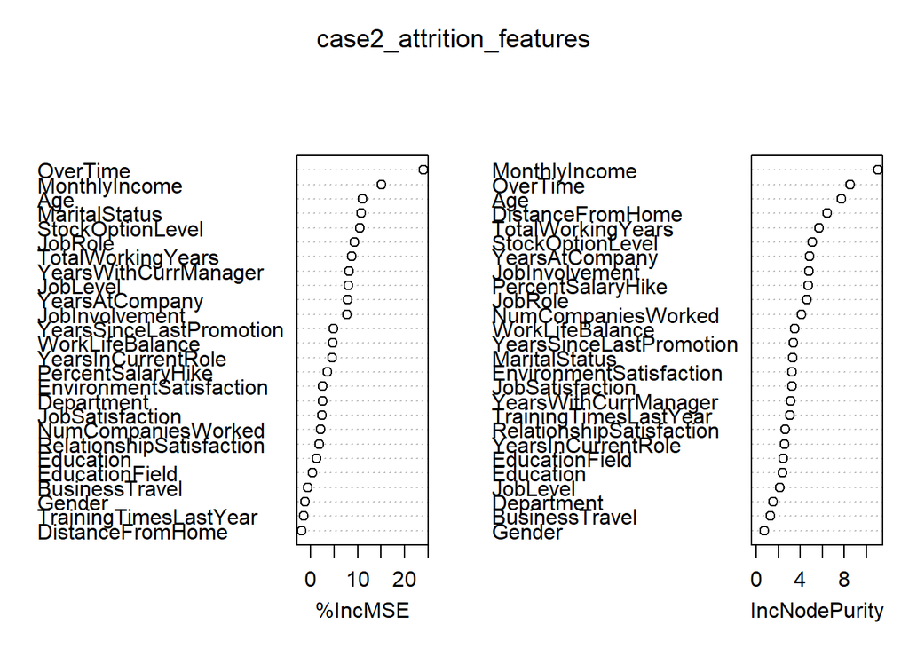

```r
varImpPlot(case2_attrition_features)
```

## Looking at Top 5 infuential variables correlation with Attrition

- Looking at the correlation plot for the top 5 influential factors that leads to attrition.
- Attrition & OverTime = 0.27
- Attrition & MOnthlyIncome = -0.15
- Attrition & StockOptionLevel = -0.15
- Attrition & Age = -0.15
- Attrition & MaritalStatus = 0.20

```r
attrition.factors=data.frame(OverTime=case2_numeric$OverTime,MonthlyIncome=case2$MonthlyIncome,
                             StockOptionLevel=case2_numeric$StockOptionLevel,Attrition=case2_numeric$Attrition,
                             Age=case2$Age,MaritalStatus=case2_numeric$MaritalStatus)
str(attrition.factors)
```

```
## 'data.frame':    870 obs. of  6 variables:
##  $ OverTime        : int  1 1 1 1 2 1 2 2 2 1 ...
##  $ MonthlyIncome   : int  4403 19626 9362 10422 3760 8793 2127 6694 2220 5063 ...
##  $ StockOptionLevel: int  1 0 0 2 0 2 0 3 1 1 ...
##  $ Attrition       : int  1 1 1 1 1 1 1 1 1 1 ...
##  $ Age             : int  32 40 35 32 24 27 41 37 34 34 ...
##  $ MaritalStatus   : int  1 3 3 2 3 1 2 1 2 2 ...
```

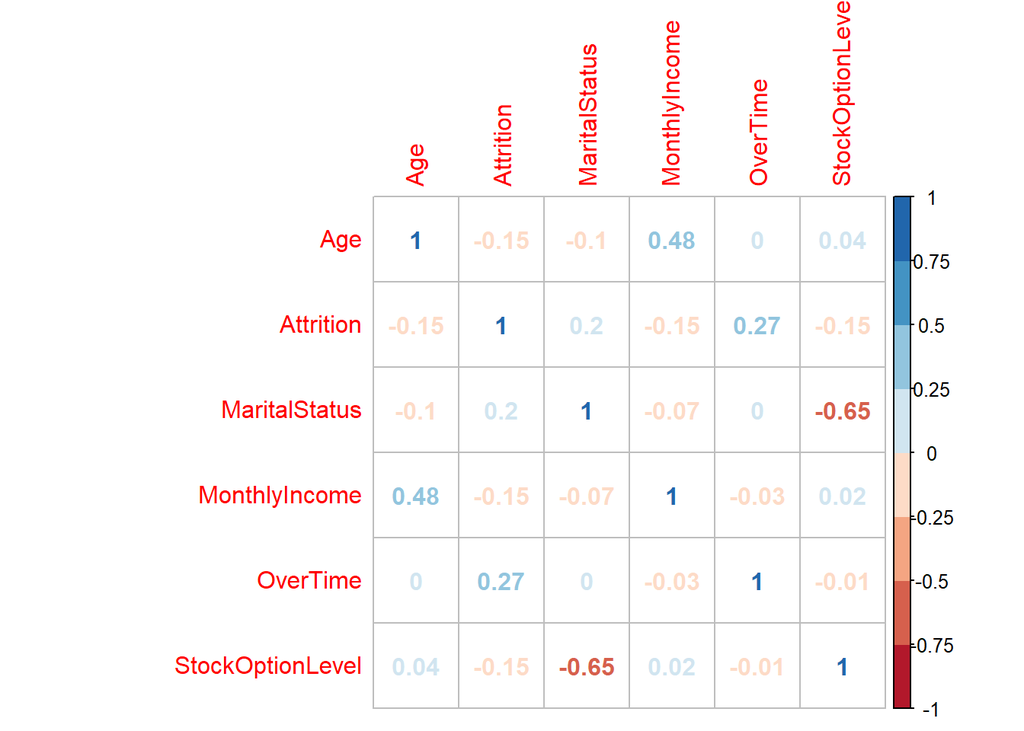

```r
corrplot(cor(attrition.factors), order = "alphabet",
         col = brewer.pal(n = 8, name = "RdBu"),method="number")
```

```r
cor(case2_numeric$MaritalStatus,case2_numeric$Attrition)
```

```
## [1] 0.197015
```

## Looking at OverTime for Attrition

Visually looking at the graph it seems like the employees doing Over time are more likely to leave.

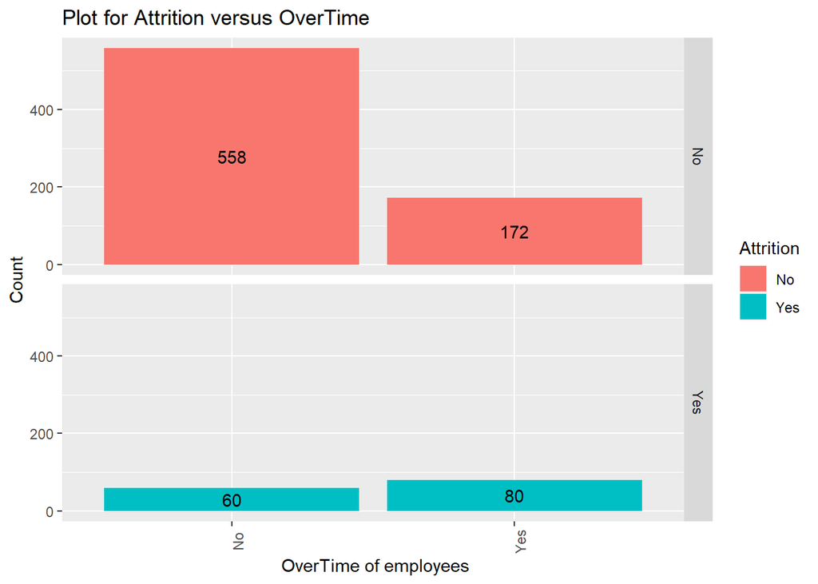

```r
ggplot(case2,aes(fill=Attrition,x=OverTime))+geom_bar(position="stack",stat="count",na.rm = TRUE)+
  theme(axis.text.x = element_text(angle = 90))+geom_text(aes(label=..count..),stat="count",position=position_stack(0.5))+facet_grid(rows = vars(Attrition))+ xlab(" OverTime of employees")+ylab("Count")+ggtitle("Plot for Attrition versus OverTime")
```

## Looking at Monthly Income for Attrition

Visually looking at the graph it seems like the employees earning Under 5000 are more likely to leave.

Numerically it is approximately 70.71% of the employees with Attrition=Yes.

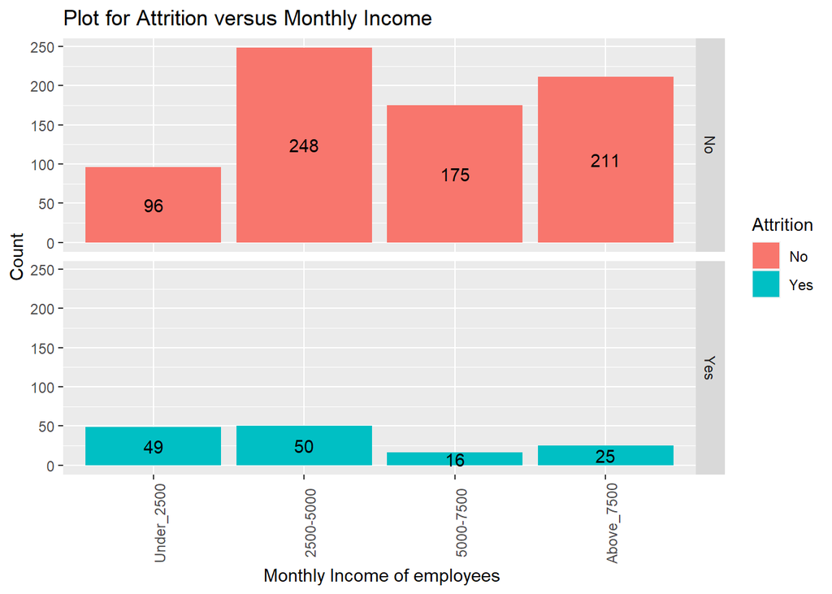

```r
ggplot(case2,aes(fill=Attrition,x=MonthlyIncome.categorize))+geom_bar(position="stack",stat="count",na.rm = TRUE)+
  theme(axis.text.x = element_text(angle = 90))+geom_text(aes(label=..count..),stat="count",position=position_stack(0.5))+facet_grid(rows = vars(Attrition))+ xlab(" Monthly Income of employees")+ylab("Count")+ggtitle("Plot for Attrition versus Monthly Income")
```

## Looking at Stock Option Level for Attrition

Visually looking at the graph it seems like the employees having 0 Stock Option Level are more likely to leave.

Numerically it is approximately 70.0% of the employees with Attrition=Yes.

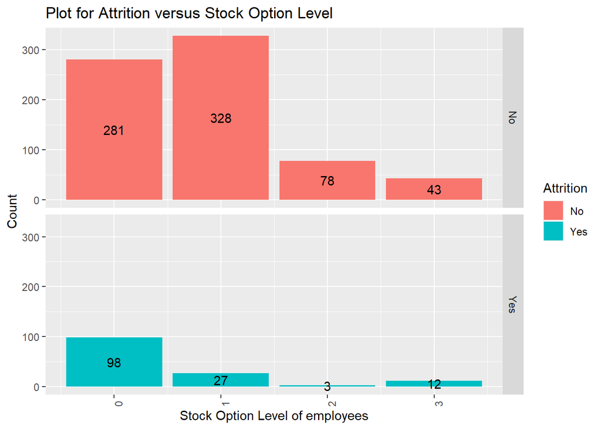

```r
ggplot(case2,aes(fill=Attrition,x=StockOptionLevel))+geom_bar(position="stack",stat="count",na.rm = TRUE)+
  theme(axis.text.x = element_text(angle = 90))+geom_text(aes(label=..count..),stat="count",position=position_stack(0.5))+facet_grid(rows = vars(Attrition))+ xlab("Stock Option Level of employees")+ylab("Count")+ggtitle("Plot for Attrition versus Stock Option Level")
```

## Looking at Age for Attrition

Visually looking at the graph it seems like the employees of 19 to 30 years age are more likely to leave.

Numerically it is approximately 40.71% of the employees with Attrition=Yes.

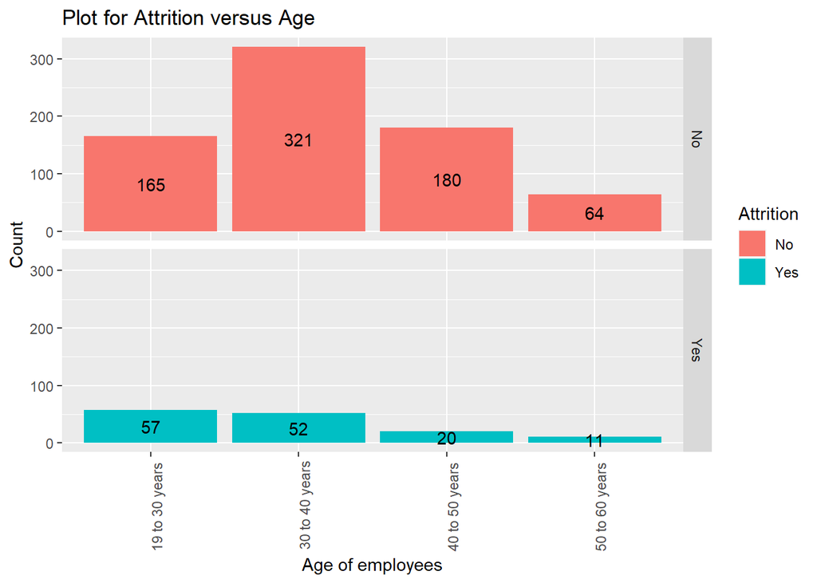

```r
ggplot(case2,aes(fill=Attrition,x=AgeEmp))+geom_bar(position="stack",stat="count",na.rm = TRUE)+
  theme(axis.text.x = element_text(angle = 90))+geom_text(aes(label=..count..),stat="count",position=position_stack(0.5))+facet_grid(rows = vars(Attrition))+ xlab("Age of employees")+ylab("Count")+ggtitle("Plot for Attrition versus Age")
```

## Looking at Marital Status for Attrition

Visually looking at the graph it seems like the employees who are single are more likely to leave.

Numerically it is approximately 50% of the employees with Attrition=Yes.

93.71% divorced employees are likely to stay.

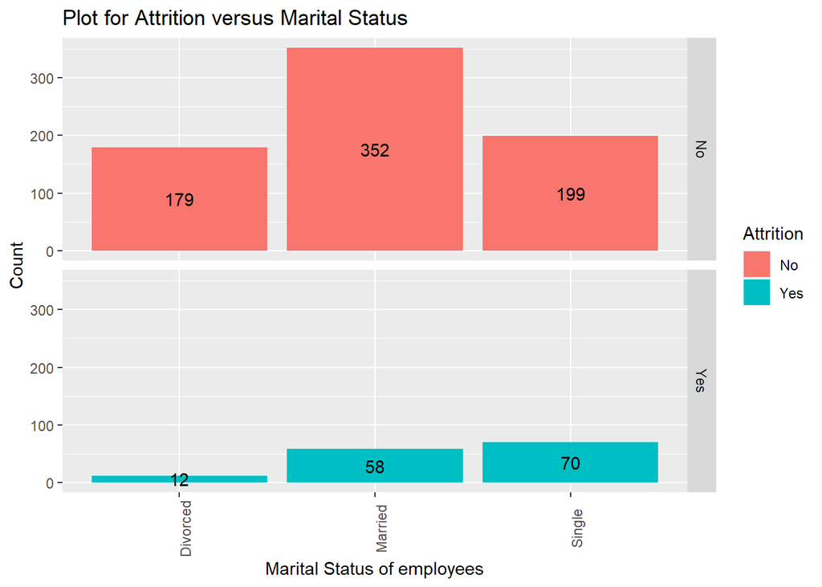

```r
ggplot(case2,aes(fill=Attrition,x=MaritalStatus))+geom_bar(position="stack",stat="count",na.rm = TRUE)+
  theme(axis.text.x = element_text(angle=90))+geom_text(aes(label=..count..),stat="count",position=position_stack(0.5))+
facet_grid(rows = vars(Attrition))+ xlab("Marital Status of employees")+ylab("Count")+ggtitle("Plot for Attrition versus Marital Status")
```

## Building the model

Now we will focus on Attrition and will implement the following algorithms for building the model:

### K-Nearest Neighbor(KNN) Classifier

### Logistic Regression

We need to measure the models:

- Accuracy: correct results / all results
- Sensitivity: correctly predicted Attrition:No / All actual “No”
- Specificity: correctly predicted Attrition:Yes / All actual “Yes”

```r
dim(case2)
```

```
## [1] 870  33
```

```r
case2_attrition.knn=case2[,-c(28,29,30,31,32,33)]
str(case2_attrition.knn)
```

```
## 'data.frame':    870 obs. of  27 variables:
##  $ Age                     : int  32 40 35 32 24 27 41 37 34 34 ...
##  $ Attrition               : chr  "No" "No" "No" "No" ...
##  $ BusinessTravel          : chr  "Travel_Rarely" "Travel_Rarely" "Travel_Frequently" "Travel_Rarely" ...
##  $ Department              : chr  "Sales" "Research & Development" "Research & Development" "Sales" ...
##  $ DistanceFromHome        : int  13 14 18 1 2 10 5 10 10 10 ...
##  $ Education               : int  4 3 2 4 1 2 5 4 4 4 ...
##  $ EducationField          : chr  "Life Sciences" "Medical" "Life Sciences" "Marketing" ...
##  $ EnvironmentSatisfaction : int  2 3 3 3 1 4 2 4 3 4 ...
##  $ Gender                  : chr  "Male" "Male" "Male" "Female" ...
##  $ JobInvolvement          : int  3 2 3 3 3 3 4 2 3 2 ...
##  $ JobLevel                : int  2 5 3 3 1 3 1 2 1 2 ...
##  $ JobRole                 : chr  "Sales Executive" "Research Director" "Manufacturing Director" "Sales Executive" ...
##  $ JobSatisfaction         : int  4 3 4 4 4 1 3 4 3 3 ...
##  $ MaritalStatus           : chr  "Divorced" "Single" "Single" "Married" ...
##  $ MonthlyIncome           : int  4403 19626 9362 10422 3760 8793 2127 6694 2220 5063 ...
##  $ NumCompaniesWorked      : int  2 1 2 1 1 1 2 2 1 1 ...
##  $ OverTime                : chr  "No" "No" "No" "No" ...
##  $ PercentSalaryHike       : int  11 14 11 19 13 21 12 14 19 14 ...
##  $ RelationshipSatisfaction: int  3 1 3 3 3 3 1 3 4 2 ...
##  $ StockOptionLevel        : int  1 0 0 2 0 2 0 3 1 1 ...
##  $ TotalWorkingYears       : int  8 21 10 14 6 9 7 8 1 8 ...
##  $ TrainingTimesLastYear   : int  3 2 2 3 2 4 5 5 2 3 ...
##  $ WorkLifeBalance         : int  2 4 3 3 3 2 2 3 3 2 ...
##  $ YearsAtCompany          : int  5 20 2 14 6 9 4 1 1 8 ...
##  $ YearsInCurrentRole      : int  2 7 2 10 3 7 2 0 1 2 ...
##  $ YearsSinceLastPromotion : int  0 4 2 5 1 1 0 0 0 7 ...
##  $ YearsWithCurrManager    : int  3 9 2 7 3 7 3 0 0 7 ...
```

```r
attrition.partition <- createDataPartition(case2_attrition.knn$Attrition, p = 0.75, list = F)
attrition.train <- case2_attrition.knn[attrition.partition,]
attrition.test <- case2_attrition.knn[-attrition.partition,]

# validate train and test sets
head(attrition.train)
```

```
##   Age Attrition    BusinessTravel             Department DistanceFromHome
## 1  32        No     Travel_Rarely                  Sales               13
## 3  35        No Travel_Frequently Research & Development               18
## 4  32        No     Travel_Rarely                  Sales                1
## 5  24        No Travel_Frequently Research & Development                2
## 6  27        No Travel_Frequently Research & Development               10
## 7  41        No     Travel_Rarely Research & Development                5
##   Education   EducationField EnvironmentSatisfaction Gender JobInvolvement
## 1         4    Life Sciences                       2   Male              3
## 3         2    Life Sciences                       3   Male              3
## 4         4        Marketing                       3 Female              3
## 5         1 Technical Degree                       1 Female              3
## 6         2    Life Sciences                       4   Male              3
## 7         5          Medical                       2   Male              4
##   JobLevel                JobRole JobSatisfaction MaritalStatus MonthlyIncome
```

[output cut: 34 more lines]

```r
head(attrition.test)
```

```
##    Age Attrition    BusinessTravel             Department DistanceFromHome
## 2   40        No     Travel_Rarely Research & Development               14
## 8   37        No     Travel_Rarely                  Sales               10
## 20  44        No     Travel_Rarely Research & Development                1
## 23  43        No Travel_Frequently Research & Development                9
## 25  33        No     Travel_Rarely Research & Development                1
## 29  53       Yes     Travel_Rarely                  Sales               24
##    Education EducationField EnvironmentSatisfaction Gender JobInvolvement
## 2          3        Medical                       3   Male              2
## 8          4  Life Sciences                       4 Female              2
## 20         4  Life Sciences                       2   Male              4
## 23         5        Medical                       4   Male              3
## 25         3  Life Sciences                       2 Female              2
## 29         4  Life Sciences                       1   Male              3
##    JobLevel                   JobRole JobSatisfaction MaritalStatus
```

[output cut: 34 more lines]

```r
dim(attrition.train)
```

```
## [1] 653  27
```

```r
dim(attrition.test)
```

```
## [1] 217  27
```

## K-Nearest Neighbor for Attrition

In the K-Nearest Neighbor(KNN), we will use 5-fold cross validation and 50 repeats to create the model for predicting the attrition.

```r
set.seed(200)
train.knn<- trainControl(
  method = "repeatedcv",
  number = 5,
  repeats = 50,
  summaryFunction = twoClassSummary,
  classProbs = TRUE
)

# KNN on Training Set

attrition.knn <- train(
  Attrition ~ .,
  data = attrition.train,
  method = "knn",
  metric = "Spec",
  trControl = train.knn,
  preProcess = c("center","scale"),
  tuneLength = 20
)

# Adding predictions to Test Data
predict(attrition.knn, newdata = attrition.test ) -> attrition.test$Attrition_KNN
# creating confusion matrix
confusionMatrix(
  table(attrition.test$Attrition, attrition.test$Attrition_KNN )
)
```

```
## Confusion Matrix and Statistics
##
##
##        No Yes
##   No  179   3
##   Yes  30   5
##
##                Accuracy : 0.8479
##                  95% CI : (0.7931, 0.8929)
##     No Information Rate : 0.9631
##     P-Value [Acc > NIR] : 1
##
##                   Kappa : 0.1836
##
##  Mcnemar's Test P-Value : 6.011e-06
##
##             Sensitivity : 0.8565
##             Specificity : 0.6250
##          Pos Pred Value : 0.9835
##          Neg Pred Value : 0.1429
##              Prevalence : 0.9631
##          Detection Rate : 0.8249
##    Detection Prevalence : 0.8387
##       Balanced Accuracy : 0.7407
##
##        'Positive' Class : No
##
```

## Random Forest for Attrition

- We obtained the accuracy above 85%, sensitivity above 85% and specificity above 70% everytime we run the model with different train and test set values.

```r
set.seed(200)

train.knn<- trainControl(
  method = "repeatedcv",
  number = 5,
  repeats = 50,
  summaryFunction = twoClassSummary,
  classProbs = TRUE
)
train.forest<- trainControl(
  method = "repeatedcv",
  number = 5,
  repeats=25
)
metric="Accuracy"

# Random Forest
train(as.factor(Attrition) ~ .,
  data = attrition.train,
  method = "rf",
  metric = "Accuracy",
  trControl = train.forest


) -> attrition.rf

predict(attrition.rf, newdata = attrition.test ) -> attrition.test$Attrition_RF
# creating confusion matrix
confusionMatrix(
  table(attrition.test$Attrition, attrition.test$Attrition_RF )
)
```

```
## Confusion Matrix and Statistics
##
##
##        No Yes
##   No  179   3
##   Yes  28   7
##
##                Accuracy : 0.8571
##                  95% CI : (0.8034, 0.9008)
##     No Information Rate : 0.9539
##     P-Value [Acc > NIR] : 1
##
##                   Kappa : 0.2579
##
##  Mcnemar's Test P-Value : 1.629e-05
##
##             Sensitivity : 0.8647
##             Specificity : 0.7000
##          Pos Pred Value : 0.9835
##          Neg Pred Value : 0.2000
##              Prevalence : 0.9539
##          Detection Rate : 0.8249
##    Detection Prevalence : 0.8387
##       Balanced Accuracy : 0.7824
##
##        'Positive' Class : No
##
```

## Logistic Regression for Attrition

- We obtained the accuracy above 85%, sensitivity above 85% and specificity above 70% everytime we run the model with different train and test set values.

```r
train.glm<- trainControl(
  method = "repeatedcv",
  number = 5,
  repeats = 50,
)
set.seed(200)
attrition.glm.model <- train(as.factor(Attrition)~., attrition.train , method = 'glm',trControl = train.forest)
```

[output not shown]

[output cut: 184 more lines]

[output not shown]

```r
train=case2_numeric
glm.fit=glm(Attrition~.,data=train)
#Predict
attrition.glm.pred <- predict(attrition.glm.model,newdata=attrition.test)
#Print confusion matrix
confusionMatrix(
  table(attrition.test$Attrition, attrition.glm.pred )
)
```

```
## Confusion Matrix and Statistics
##
##      attrition.glm.pred
##        No Yes
##   No  178   4
##   Yes  20  15
##
##                Accuracy : 0.8894
##                  95% CI : (0.8399, 0.9278)
##     No Information Rate : 0.9124
##     P-Value [Acc > NIR] : 0.9034
##
##                   Kappa : 0.4987
##
##  Mcnemar's Test P-Value : 0.0022
##
##             Sensitivity : 0.8990
##             Specificity : 0.7895
##          Pos Pred Value : 0.9780
##          Neg Pred Value : 0.4286
##              Prevalence : 0.9124
##          Detection Rate : 0.8203
##    Detection Prevalence : 0.8387
##       Balanced Accuracy : 0.8442
##
##        'Positive' Class : No
##
```

## Predictions for Attrition

### Validating KNN on Entire Training Data Set

For the prediction on the entire training set, we found the following results:

- We obtained the accuracy above 80%, sensitivity above 80% and specificity above 80% everytime we run the model entire training set.

```r
# generating predictions on test data
case2$Attrition_KNN <- predict(attrition.knn, newdata = case2)

# creating confusion matrix for KNN
confusionMatrix(
  table(case2$Attrition, case2$Attrition_KNN )
)
```

```
## Confusion Matrix and Statistics
##
##
##        No Yes
##   No  724   6
##   Yes 112  28
##
##                Accuracy : 0.8644
##                  95% CI : (0.8398, 0.8864)
##     No Information Rate : 0.9609
##     P-Value [Acc > NIR] : 1
##
##                   Kappa : 0.2763
##
##  Mcnemar's Test P-Value : <2e-16
##
##             Sensitivity : 0.8660
##             Specificity : 0.8235
##          Pos Pred Value : 0.9918
##          Neg Pred Value : 0.2000
##              Prevalence : 0.9609
##          Detection Rate : 0.8322
##    Detection Prevalence : 0.8391
##       Balanced Accuracy : 0.8448
##
##        'Positive' Class : No
##
```

### Validating Random Forest on Entire Training Data Set

For the prediction on the entire training set, we found the following results:

- We obtained the accuracy above 90%, sensitivity above 90% and specificity above 90% everytime we run the model entire training set.

```r
# generating predictions on test data
case2$Attrition_RF <- predict(attrition.rf, newdata = case2)

# creating confusion matrix for RF
confusionMatrix(
  table(case2$Attrition, case2$Attrition_RF )
)
```

```
## Confusion Matrix and Statistics
##
##
##        No Yes
##   No  727   3
##   Yes  28 112
##
##                Accuracy : 0.9644
##                  95% CI : (0.9498, 0.9757)
##     No Information Rate : 0.8678
##     P-Value [Acc > NIR] : < 2.2e-16
##
##                   Kappa : 0.8578
##
##  Mcnemar's Test P-Value : 1.629e-05
##
##             Sensitivity : 0.9629
##             Specificity : 0.9739
##          Pos Pred Value : 0.9959
##          Neg Pred Value : 0.8000
##              Prevalence : 0.8678
##          Detection Rate : 0.8356
##    Detection Prevalence : 0.8391
##       Balanced Accuracy : 0.9684
##
##        'Positive' Class : No
##
```

### Validating Logistic Regression on Entire Training Data Set

For the prediction on the entire training set, we found the following results:

- We obtained the accuracy above 85%, sensitivity above 85% and specificity above 75% everytime we run the model entire training set.

```r
# generating predictions on test data
case2$Attrition_GLM <- predict(attrition.glm.model, newdata = case2)

# creating confusion matrix for RF
confusionMatrix(
  table(case2$Attrition, case2$Attrition_GLM )
)
```

```
## Confusion Matrix and Statistics
##
##
##        No Yes
##   No  708  22
##   Yes  69  71
##
##                Accuracy : 0.8954
##                  95% CI : (0.8731, 0.9149)
##     No Information Rate : 0.8931
##     P-Value [Acc > NIR] : 0.4402
##
##                   Kappa : 0.5519
##
##  Mcnemar's Test P-Value : 1.42e-06
##
##             Sensitivity : 0.9112
##             Specificity : 0.7634
##          Pos Pred Value : 0.9699
##          Neg Pred Value : 0.5071
##              Prevalence : 0.8931
##          Detection Rate : 0.8138
##    Detection Prevalence : 0.8391
##       Balanced Accuracy : 0.8373
##
##        'Positive' Class : No
##
```

## Reading the original test data for Attrition and generating the predictions

The predictions generated by KNN, Random Forest, and Logistic Regression are stored in the original test data setin separate variables with following names :

- Attrition_KNN = Predictions for K-Nearest Neighbor
- Attrition_RF = Predictions for Random Forest
- Attrition_GLM = Predictions for Logistic Regression

```r
NoAttrition.df=read.csv("https://raw.githubusercontent.com/RashmiAPatel19/SMU_MSDS_6306_CaseStudy2_Spring2021/main/CaseStudy2CompSet%20No%20Attrition.csv",header=TRUE)
head(NoAttrition.df)
```

```
##     ID Age    BusinessTravel DailyRate             Department DistanceFromHome
## 1 1171  35     Travel_Rarely       750 Research & Development               28
## 2 1172  33     Travel_Rarely       147        Human Resources                2
## 3 1173  26     Travel_Rarely      1330 Research & Development               21
## 4 1174  55     Travel_Rarely      1311 Research & Development                2
## 5 1175  29     Travel_Rarely      1246                  Sales               19
## 6 1176  51 Travel_Frequently      1456 Research & Development                1
##   Education  EducationField EmployeeCount EmployeeNumber
## 1         3   Life Sciences             1           1596
## 2         3 Human Resources             1           1207
## 3         3         Medical             1           1107
## 4         3   Life Sciences             1            505
## 5         3   Life Sciences             1           1497
## 6         4         Medical             1            145
##   EnvironmentSatisfaction Gender HourlyRate JobInvolvement JobLevel
```

[output cut: 41 more lines]

```r
dim(NoAttrition.df)
```

```
## [1] 300  35
```

## Storing the predictions in the new csv files

We have saved the predictions of the original test data in the Attrition_KNN.csv, Attrition_RF.csv and Attrition_GLM.csv

```r
# creating new attrition in original test data with KNN model predicted Attrition
NoAttrition.df$Attrition_KNN <- predict(attrition.knn, NoAttrition.df)
output.knn=data.frame(Id=NoAttrition.df$ID,NoAttrition.df$Attrition_KNN)

# creating new attrition in original test data with Random Forest model predicted Attrition
NoAttrition.df$Attrition_RF <- predict(attrition.rf, NoAttrition.df)
output.rf=data.frame(Id=NoAttrition.df$ID,NoAttrition.df$Attrition_RF)

# creating new attrition in original test data with Logistic Regression model predicted Attrition
NoAttrition.df$Attrition_GLM <- predict(attrition.glm.model, NoAttrition.df)
output.glm=data.frame(Id=NoAttrition.df$ID,NoAttrition.df$Attrition_GLM)

head(output.knn)
```

```
##     Id NoAttrition.df.Attrition_KNN
## 1 1171                           No
## 2 1172                           No
## 3 1173                           No
## 4 1174                           No
## 5 1175                           No
## 6 1176                           No
```

```r
head(output.rf)
```

```
##     Id NoAttrition.df.Attrition_RF
## 1 1171                          No
## 2 1172                          No
## 3 1173                          No
## 4 1174                          No
## 5 1175                          No
## 6 1176                          No
```

```r
head(output.glm)
```

```
##     Id NoAttrition.df.Attrition_GLM
## 1 1171                           No
## 2 1172                           No
## 3 1173                           No
## 4 1174                           No
## 5 1175                           No
## 6 1176                          Yes
```

```r
write.csv(output.knn,file="Attrition_KNN.csv",row.names = FALSE)
write.csv(output.rf,file="Attrition_RF.csv",row.names = FALSE)
write.csv(output.glm,file="Attrition_GLM.csv",row.names = FALSE)
```